# Lectures on the design and analysis of experiments

Macartan Humphreys

# 1 Roadmap

1. Intro: | Course outline, tools
2. Experimenting: | questions, workflow, ethics
3. Causality: Fundamental problems, questions, and answers
4. Estimation: Answer Strategies
5. Design: Experimental Design and Evaluation
6. Topics: Specific experimental design

# 2 Intro

## 2.1 Getting started

- General aims and structure
- Expectations

## 2.2 Aims and items

- Primary focus is training on how to *do* experiments; not just knowledge of good experiments
- Deep understanding of key ideas in causal inference
- Transportable tools for understanding how to evaluate and improve design
- Practice!

### 2.2.1 Syllabus and resources

- https://macartan.github.io/ci for all resources
- https://macartan.github.io/ci/syllabus_experiments_2026.pdf
- Git repo https://github.com/macartan/ci
- [Student survey](https://cloud.wzb.eu/apps/forms/s/6Sdi6JEYTS59c6rMJCEcYErJ): **Please fill this out today**.

### 2.2.2 The topics

| Day | Topic | Activity |
| --- | --- | --- |
| 1: 1/9 | **Getting started** Outline | In-class exercise, intro to field experiment |
| 2: 1/16 | **Doing experiments**: Workflows; ethics | Presentation of plans, ethics application |
| 3: 1/30 | **Causality**: Foundations, Inquiries | Field reports |
| 4: 2/6 | **Answer strategies**: Estimation and Inference | Discussion of findings 1; Proposals 2 |
| 5: 2/20 | **Data strategies** and **Design evaluation** `DeclareDesign`, Assignments, Design evaluation | Proposal refinements 2 |
| 6: 2/27 | **Topics**: Survey experiments, Spillovers, Downstream experimentation | Design declarations and ethics applications |

### 2.2.3 Hands on!

We hope to run three experiments:

1. Today, simulated experiments by hand
2. Over the next four weeks (completed by 6 Feb): A field experimental variation of Choi, Poertner, and Sambanis (2023)
3. Last weeks development of designs to implement in collective survey experiment (admitted based on external review and subject to ethics approval and implemented likely after class ends). Expect to have space for four projects (individual or collective).

## 2.3 Responsibilities

### 2.3.1 Required

- Do the readings and take part in discussion (30%)
- Take part in (field) experiment I (30%)
- Design an experiment as a candidate for (survey) experiment II (40%)

### 2.3.2 Optional

- Prepare a research design or short paper, perhaps building on existing work. Typically this contains:
  - a problem statement
  - a description of an experimental strategy to address the problem
  - empirical (ideally) or simulation based results (ok)
  - a discussion of implications
  - A passing paper will illustrate identify a causal effect of substantive interest credibly; a good paper will innovate on method or topic.

## 2.4 Support

- Office hours: Friday afternoons after class: 2 - 4
- Lennard: Office hours
- Email

## 2.5 Let’s go 1

### 2.5.1 Task

We are going to do some experiments by hand. You choose assignment schemes and analysis plans.

- You have been given an envelope with 20 cards. Each card has two numbers. One in black lettering (on white) and one in white lettering (on black). On the other side of the card there may or may not be writing.
- Your job is to figure out whether–on average–the black numbers are larger or smaller than the white numbers or the same.

### 2.5.2 But

- **The catch**: when you turn over a card you are only allowed to read the black number *or* the white number (honor code!!). What’s more: you have to decide *before reading the card* which number you will look at (though of course you can see the symbol on the card, if there is one, before reading the numbers)
- To do: Access the complete procedure sheet, get a pack of cards, go!

## 2.6 Let’s go 2

### 2.6.1 Task

We are collectively going to try to replicate an experimental design that was implemented in Germany.

We are free to modify this design as will. Our goal is to:

- Modify the design (or not)
- Generate a pre-analysis plan, including power estimates, if we can
- File an ethics application: **HARD DEADLINE January 19**
- Actually implement it!
- Run analysis
- Short write up

We are going to make mistakes and learn to work as a team.

### 2.6.2 Starter pack I

[figure not shown]

AJPS

### 2.6.3 Starter pack I

> Why do native Europeans discriminate against Muslim immigrants? Can shared ideas between natives and immigrants reduce discrimination? We hypothesize that natives’ bias against Muslim immigrants is shaped by the belief that Muslims hold conservative attitudes about women’s rights and this ideational basis for discrimination is more pronounced among native women. We test this hypothesis in a large-scale field experiment conducted in 25 cities across Germany, during which 3,797 unknowing bystanders were exposed to brief social encounters with confederates who revealed their ideas regarding gender roles. We find significant discrimination against Muslim women, but this discrimination is eliminated when Muslim women signal that they hold progressive gender attitudes. Through an implicit association test and a follow-up survey among German adults, we further confirm the centrality of ideational stereotypes in structuring opposition to Muslims. Our findings have important implications for reducing conflict between native–immigrant communities in an era of increased cross-border migration.

### 2.6.4 Starter pack I: Results

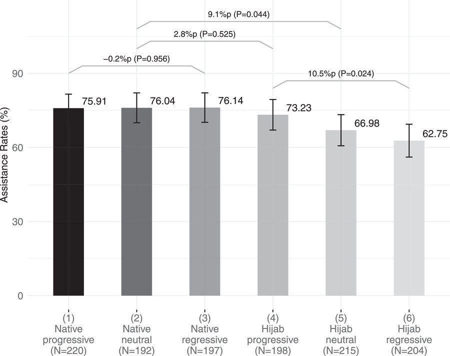

Results

### 2.6.5 Starter Pack I : A norms study

Summary:

- Inquiry: Does prejudice depend on outgroup attitudes?
- Population: People out and about
- Treatment: Random exposure to outgroup attitudes; lab-in-the-field experimental variation
- Difference in means (variant)

### 2.6.6 Starter Pack II : A protest study

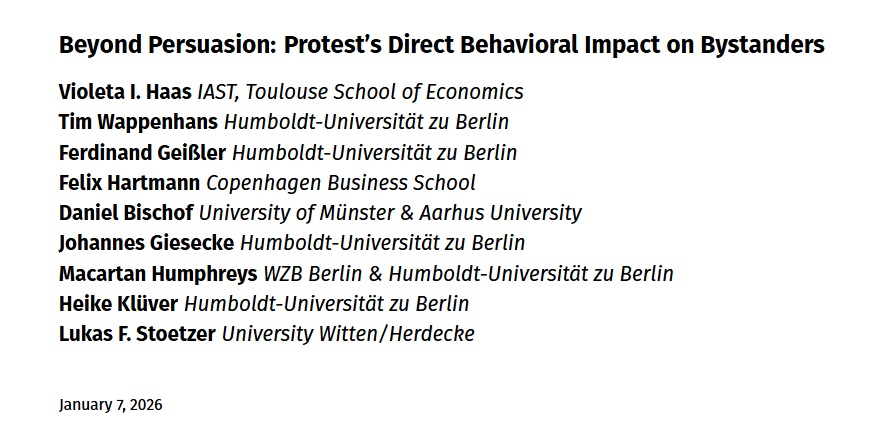

Team

### 2.6.7 Starter Pack II : A protest study

> Despite decades of scholarship on protest effects, we know little about how bystanders—citizens who observe protests without participating—are affected by them. Understanding the impact of protest on bystanders is crucial as they constitute a growing audience whose latent support, normative beliefs, and concrete actions can make or break a movement’s broader societal impact. To credibly assess the effects of protests on observers, we design and implement a field experiment in Berlin in which we randomly route pedestrians past (**treatment**) or away from (**control**) three large-scale Fridays for Future (FFF) climate strikes. Using data gathered on protest days as well as through a one-month follow-up survey, we find evidence for a substantial increase in immediate donations to climate causes but no detectable impact on climate attitudes, vote intentions, or norm perceptions. Our findings challenge the prevailing assumption in both scholarship and public discourse that protest effects operate via impacts on public opinion and call for renewed theorizing that centers on observers’ immediate behavioral activation.

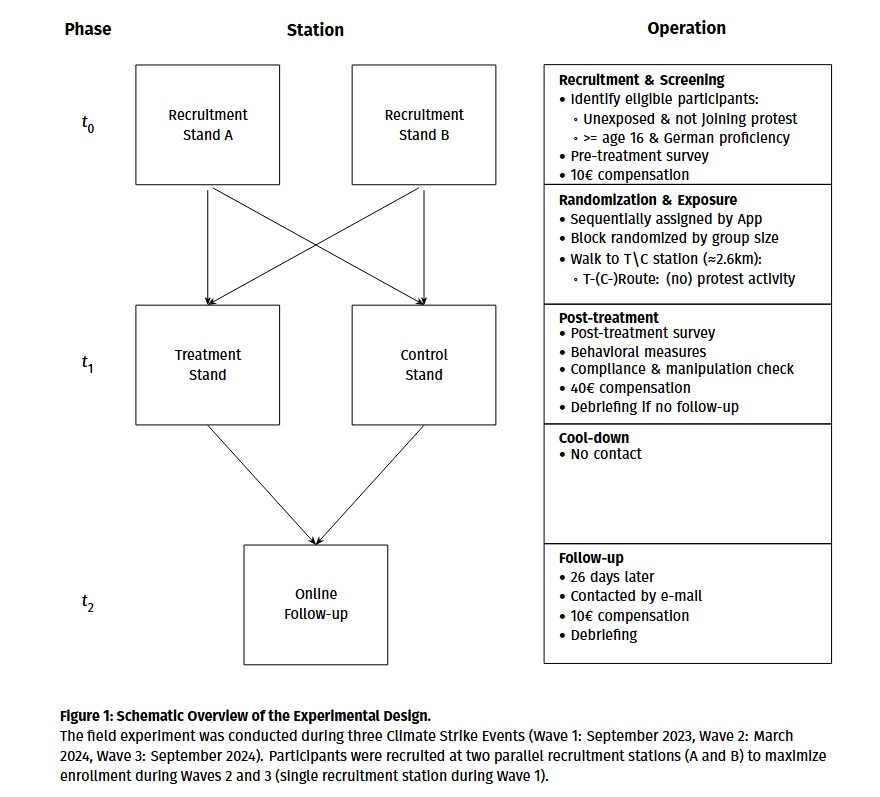

### 2.6.9 Starter Pack II : A protest study

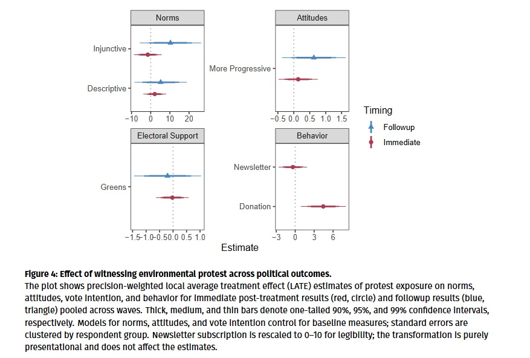

Results

### 2.6.10 Starter Pack II : A protest study

Summary:

- Inquiry: Does protest matter? *Does observing a climate protest affect beliefs or behavior?*
- Population: People out and about
- Treatment: Random exposure to protests; field experimental variation
- Difference in means (variant)

## 2.7 Let’s create some brainstorming groups

- 4 groups
- Each thinks through a possible intervention
  - Motivation: What question can you answer?
  - Treatment: What would be varied?
  - Measurement: What would outcome measures be?
  - Feasibility: Challenges to doing this rapidly and ethically in the coming weeks
  - Sketch of workteams for implementation
- Initial feedback.
- Plan to present next week (4 slides). Groups can collude.

## 2.8 Appendix: Coding Tips

### 2.8.1 Good coding rules

- https://bookdown.org/content/d1e53ac9-28ce-472f-bc2c-f499f18264a3/code.html
- https://www.r-bloggers.com/2018/09/r-code-best-practices/

### 2.8.2 Good coding rules

- Metadata first
- Call packages at the beginning: use `pacman`
- Put options at the top
- Call all data files once, at the top. Best to call directly from a public archive, when possible.
- Use functions and define them at the top: comment them; useful sometimes to illustrate what they do
- Replicate first, re-analyze second. Use sections.
- (For replications) Have subsections named after specific tables, figures or analyses

### 2.8.3 Aim

- First best: If someone has access to your `.qmd` file they can hit render or compile and the whole thing reproduces first time. So: Nothing local, everything relative: so please do not include hardcoded paths to your computer
- But: often you need ancillary files for data and code. That’s OK but aims should still be that with a self contained folder someone can open a `main.Rmd` file, hit compile and get everything. I usually have an `input` and an `output` subfolder.

### 2.8.4 Collaborative coding / writing

- Do not get in the business of passing attachments around
- Documents in some cloud: `git`, osf, Dropbox, Drive, Nextcloud
- General rule: only post non sensitive, non proprietary material
- Share self contained folders; folders contain a small set of live documents plus an archive. Old versions of documents are in archive. Only one version of the most recent document is in a main folder.
- Data is self contained folder (`in`) and is never edited directly
- Update to github frequently

### 2.8.5 Fin

# 3 Experimenting

### 3.0.1 What is an experiment?

Cox & Reid (2000) define experiments as:

> investigations in which an intervention, in all its essential elements, is under the control of the investigator.

Two types of control:

- control over assignment to treatment and
- control over the treatment itself

### 3.0.2 Two types of control:

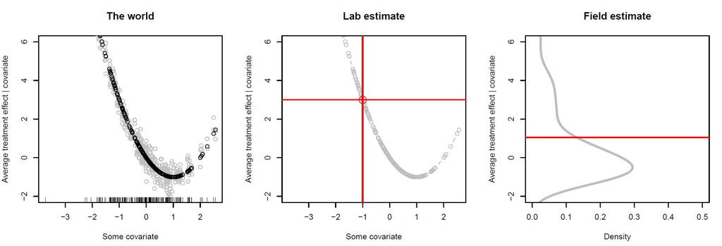

### 3.0.3 More broadly:

Experimental studies use research designs in which the researchers uses:

- *interventional* **data strategies** (to control setting or treatments)
- often with **causal** *inquiries*
- often with **design based** *answer strategies*

## 3.1 Plan

Let’s discuss:

- The four parts to any design
- The stages of an experimental design
- Examples of the kinds of questions people address
- The ethics of intervening

Then: Deep dive into discussion of actual experiments

Then: Plans for our own

## 3.2 The MIDA Framework

### 3.2.1 Four elements of any research design

- `Model`: set of models of what causes what and how
- `Inquiry`: a question stated in terms of the model
- `Data strategy`: the set of procedures we use to gather information from the world (sampling, assignment, measurement)
- `Answer strategy`: how we summarize the data produced by the data strategy

### 3.2.2 Four elements of any research design

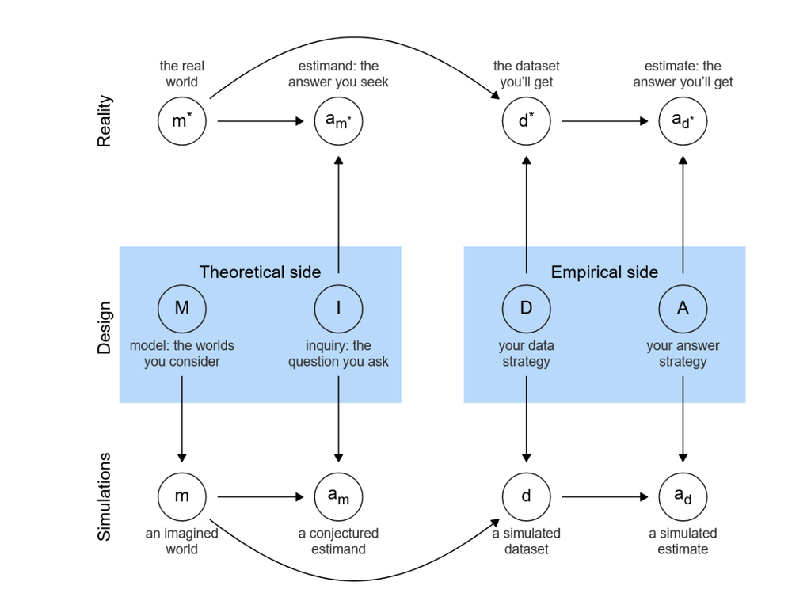

### 3.2.3 Declaration

Design declaration is telling the computer (and readers) what `M`, `I`, `D`, and `A` are.

### 3.2.4 Diagnosis

- Design diagnosis is figuring out how the design will perform under imagined conditions.
- Estimating “diagnosands” like power, bias, rmse, error rates, ethical harm, “amount learned”.
- Diagnosis takes account of model uncertainty: it aims to identify models for which the design works well and models for which it does not

### 3.2.5 Redesign

Redesign is the fine-tuning of features of the data- and answer strategies to understand how changing them affects the diagnosands

- Different sample sizes
- Different randomization procedures
- Different estimation strategies
- Implementation: effort into compliance versus more effort into sample size

### 3.2.6 Very often you have to simulate!

- Doing all this is often too hard to work out from rules of thumb or power calculators
- Specialized formulas exist for some diagnosands, but not all

## 3.3 Experimentation: Stages

1. Find a good **question**: Minimally, find an $X$ and a $Y$.
   - $X$-based motivations
   - $Y$ based motivations
   - Theory based, hypothesis based, mechanism based, replication focused
2. Survey literatures, identify **contribution**.
3. Identify partners, **resources**. Perhaps run exploratory pilot analyses.
4. Develop a **design**: Data strategy | Measurement strategy | Answer strategy
5. **Simulate** the design: Power analysis, Confirmation of properties of estimators
6. **Present**! gather feedback
7. Gather **priors**: what do others expect will happen?
8. Apply for **ethics** approval
9. Ensure **compliance** with other provisions (e.g. GDPR)!
10. **Register** a pre-analysis plan (e.g OSF, AEA)

## 3.4 Experimentation: Stages

11. Conduct **Baseline** (if needed): **With live data quality control!**
12. Implement **randomization**
13. Gather **process** observations
14. Implement **Endline**. **With live data quality control!**
15. Run **analysis**; check analysis
16. Generate **key tables**
17. **Present** to colleagues, but also present to any stakeholders
18. Prep **replication** materials. Make **data** and code available to others
19. **Writeup**
20. **Submit** [Get rejected - Submit again]

## 3.5 Experimentation: Questions

*Good questions studied well*

- Prospects and priorities

### 3.5.1 Prospects

- Whenever someone is uncertain about *something* they are doing (all the time)
- Whenever someone hits scarcity constraints
- When people have incentives to demonstrate that they are doing the right thing (careful…)

### 3.5.2 Prospects

- If you can, **start from theory** and find an intervention, rather than the other way around.
- If you can, go for *structure* rather than *gimmicks*
- In attempts to parse, beware of generating unnatural interventions (how should a voter think of a politician that describes his policy towards Korea in detail but does not mention the economy? Is *not mentioning* the economy sending an unintended message?)

### 3.5.3 Innovative designs

Randomization of

- encouragements to gain citizenship (New York)
- where police are stationed (India)
- how government tax collectors get paid (do they get a share?) (Pakistan)
- the voting rules for determining how decisions get made (Afghanistan)
- of populations to peacekeepers (Liberia)
- of ex-combatants out of their networks (Indonesia)
- students to ethnically homogeneous or ethnically diverse schools (Ethiopia)

## 3.6 Ethics

### 3.6.1 Constraint: Is it ethical to manipulate subjects for research purposes?

- There is no foundationless answer to this question.
- Belmont principles commonly used for guidance:
  1. Respect for persons
  2. Beneficence
  3. Justice
- Unfortunately, operationalizing these requires further ethical theories. (1) is often operationalized by informed consent (a very liberal idea). (2) and (3) sometimes by more utiliarian principles
- The major focus on (1) by IRBs might follow from the view that if subjects consent, then they endorse the ethical calculations made for 2 and 3 — *they* think that it is good and fair.
- Trickiness: can a study be good or fair because of implications for non-subjects?

### 3.6.2 Is it ethical to manipulate subjects for research purposes?

- Many (many) field experiments have nothing like informed consent.
- For example, whether the government builds a school in your village, whether an ad appears on your favorite radio show, and so on.
- Consider three cases:
  1. You work with a nonprofit to post (true?) posters about the crimes of politicians on billboards to see effects on **voters**
  2. You hire confederates to offer bribes to **police officers** to see if they are more likely to bend the law for coethnics
  3. The British government asks you to work on figuring out how the use of water cannons helps stop **rioters** rioting

### 3.6.3 Is it ethical to manipulate subjects for research purposes?

- Consider three cases:
  - You work with a nonprofit to post (true?) posters about the crimes of politicians on billboards to see effects on **voters**
  - You hire confederates to offer bribes to **police officers** to see if they are more likely to bend the law for coethnics
  - The British government asks you to work on figuring out how the use of water cannons helps stop **rioters** rioting
- In all cases, there is **no consent** given by subjects.
- In 2 and 3, the treatment is **possibly harmful** for subjects, and the results might also be harmful. But even in case 1, there could be major unintended harmful consequences.
- In cases 1 and 3, however, the “intervention” is within the sphere of **normal activities** for the implementer.

### 3.6.4 Constraint: Is it ethical to manipulate subjects for research purposes?

- Sometimes it is possible to use this point of difference to make a “spheres of ethics” argument for “embedded experimentation.”
- **Spheres of Ethics Argument**: Experimental research that involves manipulations that are not normally appropriate for researchers may nevertheless be ethical if:
  - Researchers and implementers agree on a **division of responsibility** where implementers take on responsibility for actions
  - Implementers have **legitimacy** to make these decisions within the sphere of the intervention
  - Implementers are indeed **materially independent** of researchers (no swapping hats)

### 3.6.5 Constraint: Is it ethical to manipulate subjects for research purposes?

- Difficulty with this argument:
  - **Question begging**: How to determine the legitimacy of the implementer? (Can we rule out Nazi doctors?)

Otherwise keep focus on consent and desist if this is not possible

### 3.6.6 APSA Guidelines

- Available [here](https://www.apsanet.org/Portals/54/diversity%20and%20inclusion%20prgms/Ethics/Final_Principles%20with%20Guidance%20with%20intro.pdf?ver=2020-04-20-211740-153)
- Used e.g. by APSR
- Below is lightly abbreviated; full text however has detailed guidelines

### 3.6.7 APSA Ethics: General [Abbr]

1. Political science researchers should respect **autonomy**, consider the **wellbeing** of participants and other people affected by their research, and be **open** about the ethical issues they face.
2. Political science researchers have an **individual responsibility** to consider the ethics of their research related activities and cannot outsource ethical reflection to review boards, other institutional bodies, or regulatory agencies.
3. These principles describe the standards of conduct and **reflexive openness** that are expected of political science researchers. … [In cases of reasonable deviations], researchers should acknowledge and justify deviations in scholarly publications and presentations of their work.

### 3.6.8 APSA Ethics: Power

4. When designing and conducting research, political scientists should be aware of **power differentials** between researcher and researched, and the ways in which such power differentials can affect the voluntariness of consent and the evaluation of risk and benefit.
1. especially with low-power or vulnerable participants
2. covert or deceptive research with more than minimal harm may sometimes be ethically permissible in research with powerful parties

### 3.6.9 APSA Ethics: Consent

5. Political science researchers should generally seek informed **consent** from individuals who are directly engaged by the research process, especially if research involves more than minimal risk of harm or if it is plausible to expect that engaged individuals would withhold consent if consent were sought.
1. **informed and voluntary**
2. **continuing** consent
3. observation of public behavior does not usually invoke this principle of consent.
4. forgoing perhaps if minimal risk, or seeking consent increases the risks for participants
5. discuss consent in publications and presentations

### 3.6.10 APSA Ethics: Deception

6. Political science researchers should **carefully consider** any use of deception and the ways in which deception can conflict with participant autonomy.
1. ask: is it plausible that engaged individuals would withhold consent if fully informed consent were sought
2. disclose, justify,, and describe steps taken to respect participant autonomy.

[Note: no general injunction against]

### 3.6.11 APSA Ethics: Harm and Trauma

7. Political science researchers should **consider the harms** associated with their research.
- Researchers should generally avoid harm when possible, minimize harm when avoidance is not possible, and not conduct research when harm is excessive.
- do not limit concern to physical and psychological risks to the participant.
8. Political science researchers should anticipate and protect individual participants from trauma stemming from participation in research.

### 3.6.12 APSA Ethics: Confidentiality

9. Political science researchers should generally keep the identities of research participants **confidential**; when circumstances require, researchers should adopt the higher standard of ensuring anonymity.
1. Researchers should clearly communicate assurances of confidentiality / anonymity
2. If confidentiality bit provided, communicate this and justify c./d. consider risks at all stages
3. Researchers who determine that it would be unethical to share materials derived from human subjects should be prepared to justify their decision to journal editors, to reviewers, etc

### 3.6.13 APSA Ethics: Impact

10. Political science researchers conducting studies on political processes should consider the broader social impacts of the research process as well as the impact on the experience of individuals directly engaged by the research. In general, political science researchers **should not compromise the integrity of political processes for research purposes without the consent of individuals that are directly engaged by the research process**.
1. cases in which research that produces impacts on political processes without consent of individuals directly engaged by the research might be appropriate. [examples]
2. Studies of interventions by third parties do not usually invoke this principle on impact. [details]
3. This principle is not intended to discourage any form of political engagement by political scientists in their non-research activities or private lives.
4. researchers should report likely impacts

### 3.6.14 APSA Ethics: Laws, Regulations, and Prospective Review

11. Political science researchers should be aware of relevant laws and regulations governing their research related activities.

### 3.6.15 APSA Ethics: Shared Responsibility

12. The responsibility to promote ethical research goes **beyond the individual researcher** or research team.
1. Mentors, advisors, dissertation committee members, and instructors
2. Graduate programs in political science should include ethics instruction in their formal and informal graduate curricula;
3. Editors and reviewers should encourage researchers to be open about the ethical decisions …
4. Journals, departments, and associations should incorporate ethical commitments into their mission, bylaws, instruction, practices, and procedures.

## 3.7 Appendix

## 3.8 Transparency & Experimentation

### 3.8.1 Transparent workflows

Experimental researchers are deeply engaged in the movement towards more transparency social science research.

- **Analytic replication.** This should be a no brainer. Set everything up so that replication is easy. Use quarto rmarkdown, or similar. Or produce your replication code as a package.

### 3.8.2 Contentious Issues

Experimental researchers are deeply engaged in the movement towards more transparency social science research.

Contentious issues (mostly):

- **Data.** How soon should you make your data available? **My view**: as soon as possibe. Along with working papers and before publication. Before it affects policy in any case. Own the ideas not the data.
  - Hard core: no citation without (analytic) replication. Perhaps. Non-replicable results should not be influencing policy.
- **Where should you make your data available?** Dataverse is focal for political science. Not personal website (mea culpa)
- **What data should you make available?** Disagreement is over how raw your data should be. **My view**: as raw as you can but at least post cleaning and pre-manipulation.

### 3.8.3 Open science checklist

Experimental researchers are deeply engaged in the movement towards more transparency social science research.

- **Should you register?**: Hard to find reasons against. But case strongest in testing phase rather than exploratory phase.
- **Registration**: When should you register? **My view:** Before treatment assignment. (Not just before analysis, mea culpa)
- **Registration**: Should you deviate from a preanalysis plan if you change your mind about optimal estimation strategies. **My view:** Yes, but make the case and describe both sets of results.

### 3.8.4 Two distinct rationales for registration

- File drawer bias (Publication bias)
- Analysis bias (Fishing)

### 3.8.5 File drawer bias

– Say in truth $X$ affects $Y$ in 50% of cases.

– Researchers conduct multiple excellent studies. But they only write up the 50% that produce “positive” results.

– Even if each individual study is indisputably correct, the account in the research record – that X affects Y in 100% of cases – will be wrong.

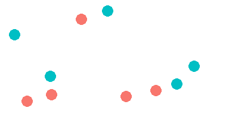

### 3.8.6 File drawer bias

– Say in truth $X$ affects $Y$ in 50% of cases.

– Researchers conduct multiple excellent studies. But they only write up the 50% that produce “positive” results.

– Even if each individual study is indisputably correct, the account in the research record – that X affects Y in 100% of cases – will be wrong.

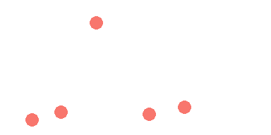

### 3.8.7 File drawer bias

Exacerbated by:

– Publication bias – the positive results get published

– Citation bias – the positive results get read and cited

– Chatter bias – the positive results gets blogged, tweeted and TEDed.

### 3.8.8 Analysis bias (Fishing)

– Say in truth $X$ affects $Y$ in 50% of cases.

– But say that researchers enjoy discretion to select measures for $X$ or $Y$, or enjoy discretion to select statistical models after seeing $X$ and $Y$ in each case.

– Then, with enough discretion, 100% of analyses may report positive effects, even if all studies get published.

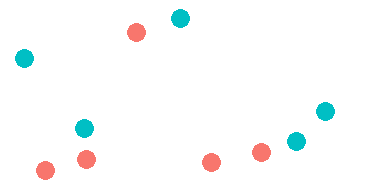

### 3.8.9 Analysis bias (Fishing)

– Say in truth $X$ affects $Y$ in 50% of cases.

– But say that researchers enjoy discretion to select measures for $X$ or $Y$, or enjoy discretion to select statistical models after seeing $X$ and $Y$ in each case.

– Then, with enough discretion, 100% of analyses may report positive effects, even if all studies get published.

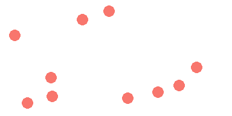

### 3.8.10 Analysis bias (Fishing)

– Try the exact fishy test [An Exact Fishy Test (https://macartan.shinyapps.io/fish/)](https://macartan.shinyapps.io/fish/)

– What’s the problem with this test?

### 3.8.11 Evidence-Proofing: Illustration

- When your conclusions do not really depend on the data
- Eg – some evidence will always support your proposition – some interpretation of evidence will always support your proposition
- Knowing the mapping from data to inference in advance gives a handle on the false positive rate.

### 3.8.12 The scope for fishing

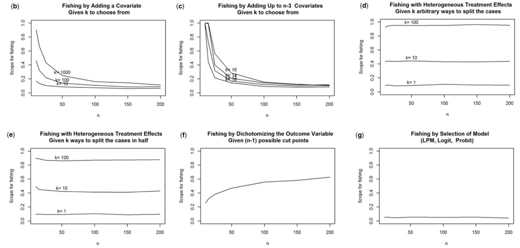

### 3.8.13 Evidence from political science

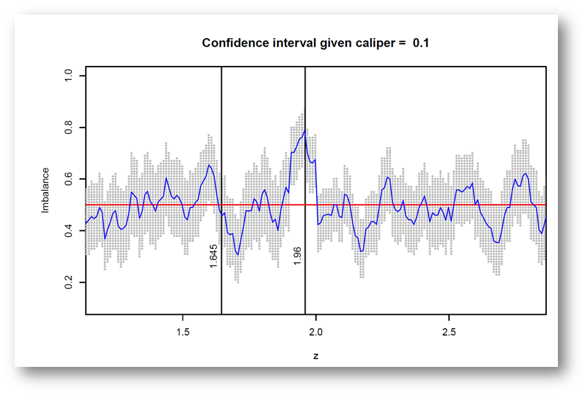

Source: Gerber and Malhotra

### 3.8.14 More evidence from TESS

- Malhotra tracked 221 TESS studies.
- 20% of the null studies were published. 65% not even written up (file drawer or anticipation of publication bias)
- 60% of studies with strong results were published.

Implications are:

- population of results not representative
- (subtler) individual published studies are also more likely to be overestimates

### 3.8.15 The problem

- Summary: we do not know when we can or cannot trust claims made by researchers.
- [Not a tradition specific claim]

### 3.8.16 Registration as a possible solution

Simple idea:

- It’s about communication:
- just say what you are planning on doing before you do it
- if you don’t have a plan, say that
- If you do things differently from what you were planning to do, say that

### 3.8.17 Worries and Myths

Lots of misunderstandings around registration

### 3.8.18 Myth: Concerns about fishing presuppose researcher dishonesty

- Fishing can happen in very subtle ways, and may seem natural and justifiable.
- Example:
  - I am interested in whether more democratic institutions result in better educational outcomes.
  - I examine the relationship between institutions and literacy and between institutions and school attendance.
  - The attendance measure is significant and the literacy one is not. Puzzled, I look more carefully at the literacy measure and see various outliers and indications of measurement error. As I think more I realize too that literacy is a slow moving variable and may not be the best measure anyhow. I move forward and start to analyze the attendance measure only, perhaps conducting new tests, albeit with the same data.

### 3.8.19 Structural challenge

Our journal review process is largely organized around advising researchers how to adjust analysis in light of findings in the data.

### 3.8.20 Myth: Fishing is technique specific

- Frequentists can do it
- Bayesians can do it too.
- Qualitative researchers can also do it.
- You can even do it with descriptive statistics

### 3.8.21 Myth: Fishing is estimand specific

- You can do it when estimating causal effects
- You can do it when studying mechanisms
- You can do it when estimating counts

### 3.8.22 Myth: Registration only makes sense for experimental studies, not for observational studies

- The key distinction is between prospective and retrospective studies.
- Not between experimental and observational studies.
- A reason (from the medical literature) why registration is especially important for experiments: because you owe it to subjects
- A reason why registration is less important for experiments: because it is more likely that the intended analysis is implied by the design in an experimental study. Researcher degrees of freedom may be greatest for observational qualitative analyses.

### 3.8.23 Worry: Registration will create administrative burdens for researchers, reviewers, and journals

- Registration will produce some burden but does not require the creation of content that is not needed anyway
- It does shift preparation of analyses forward
- And it also can increase the burden of developing analyses plans even for projects that don’t work. But that is in part, the point.
- Upside is that ultimate analyses may be much easier.

### 3.8.24 Worry: Registration will force people to implement analyses that they know are wrong

- Most arguments for registration in social science advocate for non-binding registration, where deviations from designs are possible, though they should be described.
- Even if it does not prevent them, a merit of registration is that it makes deviations visible.

### 3.8.25 Myth: Replication (or other transparency practices) obviates the need for registration

- There are lots of good things to do, including replication.
- Many of these do not substitute for each other. (How to interpret a fished replication of a fished analysis?)
- And they may likely act as complements
- Registration can clarify details of design and analysis and ensure early preparation of material. Indeed material needed for replication may be available even before data collection

### 3.8.26 Worry: Registration will put researchers at risk of scooping

- But existing registries allow people to protect registered designs for some period
- Registration may let researchers lay claim to a design

### 3.8.27 Worry: Registration will kill creativity

- This is an empirical question. However, under a nonmandatory system researchers could:
- Register a plan for structured exploratory analysis
- Decide that exploration is at a sufficiently early stage that no substantive registration is possible and proceed without registration.

### 3.8.28 Implications:

- In neither case would the creation of a registration facility prevent exploration.
- What it might do is make it less credible for someone to claim that they have tested a proposition when in fact the proposition was developed using the data used to test it.
- Registration communicates when researchers are angage in exploration or not. We love exploration and should be proud of it.

### 3.8.29 Punchline

- Do it!
- But if you have reasons to deviate, deviate *transparently*
- Don’t implement bad analysis just because you pre-registered
- Instead: reconcile

### 3.8.30 Reconciliation

Incentives and strategies

### 3.8.31 Reconciliation

Table 1: Illustration of an inquiry reconciliation table.

| Inquiry | In the preanalysis plan | In the paper | In the appendix |
| --- | --- | --- | --- |
| Gender effect | X | X |  |
| Age effect |  |  | X |

### 3.8.32 Reconciliation

Table 2: Illustration of an answer strategy reconciliation table.

| Inquiry | Following *A* from the PAP | Following *A* from the paper | Notes |
| --- | --- | --- | --- |
| Gender effect | estimate = 0.6, s.e = 0.31 | estimate = 0.6, s.e = 0.25 | Difference due to change in control variables [provide cross references to tables and code] |

# 4 Causality

Fundamental problems

## 4.1 Potential outcomes and the counterfactual approach

*Causation as difference making*

### 4.1.1 Motivation

The *intervention* based motivation for understanding causal effects:

- We want to know if a particular intervention (like aid) caused a particular outcome (like reduced corruption).
- We need to know:
  1. What happened?
  2. What would the outcome have been if there were no intervention?
- The problem:
  1. … this is hard
  2. … this is impossible

The problem in 2 is that you need to know what would have happened if things were different. You need information on a **counterfactual**.

### 4.1.2 Potential Outcomes

- For each unit, we assume that there are two **post-treatment** outcomes: $Y_i(1)$ and $Y_i(0)$.
  - $Y(1)$ is the outcome that *would* obtain *if* the unit received the treatment.
  - $Y(0)$ is the outcome that *would* obtain *if* it did not.
- The **causal effect** of Treatment (relative to Control) is: $\tau_i = Y_i(1) - Y_i(0)$
- Note:
  - The causal effect is defined at the *individual level*.
  - There is no “data generating process” or functional form.
  - The causal effect is defined relative to something else, so a counterfactual must be conceivable (did Germany cause the second world war?).
  - Are there any substantive assumptions made here so far?

### 4.1.3 Potential Outcomes

**Idea**: A causal claim is (in part) a claim about something that did not happen. This makes it metaphysical.

### 4.1.4 Potential Outcomes

Now that we have a concept of causal effects available, let’s answer two **questions**:

- TRANSITIVITY: If for a given unit $A$ causes $B$ and $B$ causes $C$, does that mean that $A$ causes $C$?

### 4.1.5 Potential Outcomes

Now that we have a concept of causal effects available, let’s answer two **questions**:

- TRANSITIVITY: If for a given unit $A$ causes $B$ and $B$ causes $C$, does that mean that $A$ causes $C$?
- A boulder is flying down a mountain. You duck. This saves your life.
- So the boulder caused the ducking and the ducking caused you to survive.
- So: *did the boulder cause you to survive?*

### 4.1.6 Potential Outcomes

CONNECTEDNESS Say $A$ causes $B$ — does that mean that there is a spatiotemporally continuous sequence of causal intermediates?

### 4.1.7 Potential Outcomes

CONNECTEDNESS Say $A$ causes $B$ — does that mean that there is a spatiotemporally continuous sequence of causal intermediates?

- Person A is planning some action $Y$; Person B sets out to stop them; person X intervenes and prevents person B from stopping person A. In this case Person A may complete their action, producing Y, without any knowledge that B and X even exist; in particular B and X need not be anywhere close to the action. So: *did X cause Y*?

### 4.1.8 Causal claims: Contribution or attribution?

The counterfactual model is about contribution and attribution in a very specific sense.

- Focus is on *non-rival* contributions
- Focus is on *conditional* attribution. Not: “what caused $Y$?” or “What is *the* cause of $Y$?”, but “did $X$ cause $Y$ given all other factors were what they were?”

### 4.1.9 Causal claims: Contribution or attribution?

Consider an outcome $Y$ that might depend on two causes $X_1$ and $X_2$:

$$Y(0,0) = 0$$
$$Y(1,0) = 0$$
$$Y(0,1) = 0$$
$$Y(1,1) = 1$$

What caused $Y$? Which cause was most important?

### 4.1.10 Causal claims: Contribution or attribution?

The counterfactual model is about attribution in a very conditional sense.

- This is problem for research programs that define “explanation” in terms of figuring out the things that cause $Y$
- Real difficulties conceptualizing what it means to say one cause is more important than another cause. What does that mean?

### 4.1.11 Causal claims: Contribution or attribution?

*Erdogan’s increasing authoritarianism was the most important reason for the attempted coup*

- More important than Turkey’s history of coups?
- What does that mean?

### 4.1.12 Causal claims: No causation without manipulation

- Some seemingly causal claims not admissible.
- To get the definition off the ground, manipulation must be imaginable (whether practical or not)
- This renders thinking about effects of race and gender difficult
- What does it mean to say that Aunt Pat voted for Brexit because she is old?

### 4.1.13 Causal claims: No causation without manipulation

- Some seemingly causal claims not admissible.
- To get the definition off the ground, manipulation must be imaginable (whether practical or not)
- This renders thinking about effects of race and gender difficult
- **Compare**: What does it mean to say that Southern counties voted for Brexit because they have many old people?

### 4.1.14 Causal claims: No causation without manipulation

More uncomfortably:

What does it mean to say that the tides are caused by the moon? What exactly do we have to imagine…

### 4.1.15 Causal claims: Causal claims are everywhere

- Jack exploited Jill
- It’s Jill’s fault that bucket fell
- Jack is the most obstructionist member of Congress
- Melania Trump stole from Michelle Obama’s speech
- Activists need causal claims

### 4.1.16 Causal claims: What is actually seen?

- We have talked about what’s potential, now what do we *observe*?
- Say $Z_i$ indicates whether the unit $i$ is assigned to treatment $(Z_i=1)$ or not $(Z_i=0)$. It describes the treatment process. Then what we observe is:
  $$Y_i = Z_iY_i(1) + (1-Z_i)Y_i(0)$$

This is sometimes called a “switching equation”

In `DeclareDesign` $Y$ is realised from potential outcomes and assignment in this way using `reveal_outcomes`

### 4.1.17 Causal claims: What is actually seen?

- Say $Z$ is a random variable, then this is a sort of data generating process. BUT the key thing to note is
  - $Y_i$ is random but the randomness comes from $Z_i$ — the potential outcomes, $Y_i(1)$, $Y_i(0)$ are fixed
  - Compare this to a regression approach in which $Y$ is random but the $X$’s are fixed. eg:
    $$Y \sim N(\beta X, \sigma^2) \text{ or } Y=\alpha+\beta X+\epsilon, \epsilon\sim N(0, \sigma^2)$$

### 4.1.18 Causal claims: The estimand and the rub

- The causal effect of Treatment (relative to Control) is:
  $$\tau_i = Y_i(1) - Y_i(0)$$
- This is what we want to estimate.
- BUT: We never can observe both $Y_i(1)$ and $Y_i(0)$!
- This is the **fundamental problem** (Holland (1986))

### 4.1.19 Causal claims: The rub and the solution

- Now for some magic. We really want to estimate:
  $$\tau_i = Y_i(1) - Y_i(0)$$
- BUT: We never can observe both $Y_i(1)$ and $Y_i(0)$
- Say we lower our sights and try to estimate an *average* treatment effect:
  $$\tau = \mathbb{E} [Y(1)-Y(0)]$$
- Now make use of the fact that
  $$\mathbb E[Y(1)-Y(0)] = \mathbb E[Y(1)]- \mathbb E [Y(0)]$$
- In words: *The average of differences is equal to the difference of averages*.
- The magic is that *while we can’t hope to measure the differences; we are good at measuring averages*.

### 4.1.20 Causal claims: The rub and the solution

- So we want to estimate $\mathbb{E} [Y(1)]$ and $\mathbb{E} [Y(0)]$.
- We know that we can estimate averages of a quantity by taking the average value from a random sample of units
- To do this here we need to select a random sample of the $Y(1)$ values and a random sample of the $Y(0)$ values, in other words, we **randomly assign** subjects to treatment and control conditions.
- When we do that we can in fact estimate:
  $$\mathbb {E}_N[Y_i(1) | Z_i = 1) - \mathbb {E}_N(Y_i(0) | Z_i = 0]$$
  which in expectation equals:
  $$\mathbb{E} [Y_i(1) | Z_i = 1 \text{ or } Z_i = 0] - \mathbb{E} [Y_i(0) | Z_i = 1 \text{ or } Z_i = 0]$$

### 4.1.21 Causal claims: The rub and the solution

- This highlights a deep connection between **random assignment** and **random sampling**: when we do random assignment *we are in fact randomly sampling from different possible worlds*.

### 4.1.22 Causal claims: The rub and the solution

This provides a **positive argument** for causal inference from randomization, rather than simply saying with randomization “everything else is controlled for”

**Let’s discuss:**

- *Does the fact that an estimate is unbiased mean that it is right?*
- *Can a randomization “fail”?*
- *Where are the covariates?*

### 4.1.23 Causal claims: The rub and the solution

**Idea**: random assignment is random sampling from potential worlds: to understand anything you find, you need to know the sampling weights

### 4.1.24 Reflection

**Idea**: We now have a *positive* argument for claiming unbiased estimation of the average treatment effect following random assignment

But is the average treatment effect a quantity of *social scientific* interest?

### 4.1.25 Potential outcomes: why randomization works

The average of the differences $\approx$ difference of averages

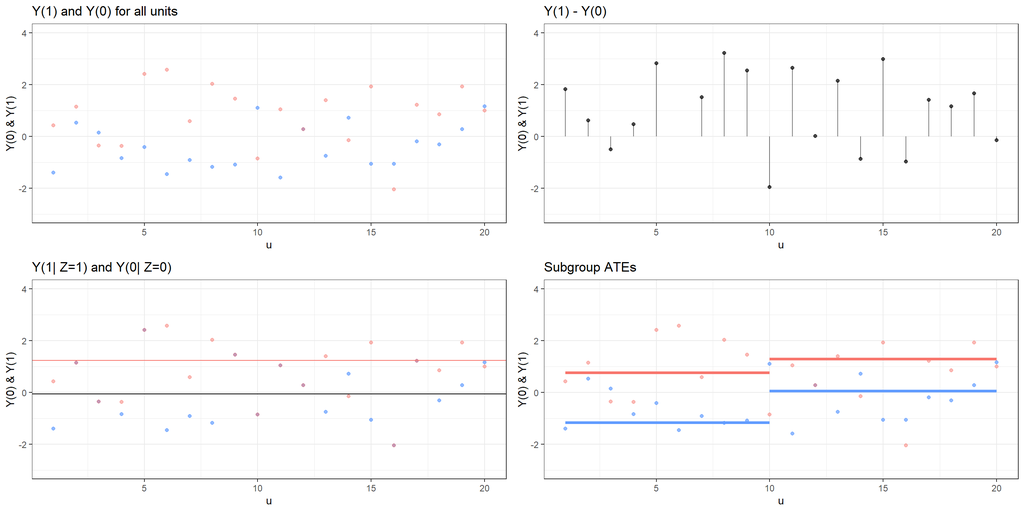

### 4.1.26 Potential outcomes: heterogeneous effects

The average of the differences $\approx$ difference of averages

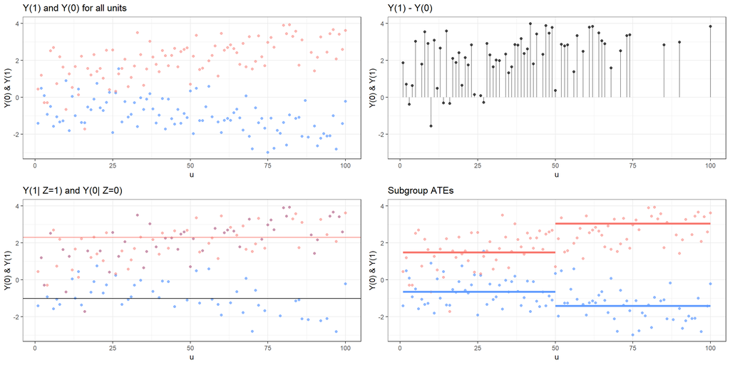

### 4.1.27 Potential outcomes: heterogeneous effects

**Question**: $\approx$ or $=$?

### 4.1.28 Exercise your potential outcomes 1

Consider the following potential outcomes table:

| Unit | Y(0) | Y(1) | $\tau_i$ |
| --- | --- | --- | --- |
| 1 | 4 | 3 |  |
| 2 | 2 | 3 |  |
| 3 | 1 | 3 |  |
| 4 | 1 | 3 |  |
| 5 | 2 | 3 |  |

**Questions for us:** What are the unit level treatment effects? What is the average treatment effect?

### 4.1.29 Exercise your potential outcomes 2

Consider the following potential outcomes table:

| In treatment? | Y(0) | Y(1) |
| --- | --- | --- |
| Yes |  | 2 |
| No | 3 |  |
| No | 1 |  |
| Yes |  | 3 |
| Yes |  | 3 |
| No | 2 |  |

**Questions for us:** Fill in the blanks.

- Assuming a constant treatment effect of $+1$
- Assuming a constant treatment effect of $-1$
- Assuming an *average* treatment effect of $0$

What is the actual treatment effect?

## 4.2 Pause

Take a short break!

[figure not shown]

## 4.3 Endogeneous subgroups

### 4.3.1 Endogeneous Subgroups

Experiments often give rise to endogenous subgroups. The potential outcomes framework can make it clear why this can cause problems.

### 4.3.2 Heterogeneous Effects with Endogeneous Categories

- Problems arise in analyses of subgroups when the categories themselves are affected by treatment
- Example from our work:
  - You want to know if an intervention affects reporting on violence against women
  - You measure the share of all subjects that experienced violence that file reports
  - The problem is that which subjects experienced violence is itself a function of treatment

### 4.3.3 Heterogeneous Effects with Endogeneous Categories

- V(t): **Violence(Treatment)**
- R(t, v): **Reporting(Treatment, Violence)**

|  | V(0) | V(1) | R(0,1) | R(1,1) | R(0,0) | R(1,0) |
| --- | --- | --- | --- | --- | --- | --- |
| Type 1 (reporter) | 1 | 1 | 1 | 1 | 0 | 0 |
| Type 2 (non reporter) | 1 | 0 | 0 | 0 | 0 | 0 |

- Expected reporting given violence in control = **Pr(Type 1)** (explanation: both types see violence but only Type 1 reports)
- Expected reporting given violence in treatment = **100%** (explanation: only Type 1 sees violence and this type also reports)

So you might infer a large effect on violence reporting.

**Question**: What is the actual effect of treatment on the propensity to report violence?

### 4.3.4 Heterogeneous Effects with Endogeneous Categories

It is possible that in truth no one’s reporting behavior has changed, what has changed is the propensity of people with different propensities to report to experience violence:

|  | Reporter | *No Violence* | *Violence* | % Report |
| --- | --- | --- | --- | --- |
| Control | Yes No | 25 25 | 25 25 | $\frac{25}{25+25}=50\%$ |
| Treatment | Yes No | 25 50 | 25 0 | $\frac{25}{25+0}=100\%$ |

### 4.3.5 Heterogeneous Effects with Endogeneous Categories

This problem can arise as easily in seemingly simple field experiments. Example:

- In one study we provided constituents with information about performance of politicians
- We told politicians in advance so that they could take action
- We wanted to see whether voters punished poorly performing politicians

What’s the problem?

### 4.3.6 Endogeneous Categories: Test yourself

Question for us:

- Quotas for women are randomly placed in a set of constituencies in year 1. All winners in these areas are women; in other areas only some are.
- In year 2 these quotas are then lifted.

Which problems face an endogenous subgroup issue?:

### 4.3.7 Endogeneous Categories: Test yourself

Which problems face an endogenous subgroup issue?:

1. You want to estimate the likelihood that a woman will stand for reelection in treatment versus control areas in year 2.
2. You want to estimate whether incumbents are more likely to be reelected in treatment versus control areas in year 2
3. You want to estimate how much treatment areas have more re-elected incumbents in elections in year 2 compared to control

### 4.3.8 Endogeneous Categories: Responses

In such cases you can:

- Examine the joint distribution of multiple outcomes
- Condition on pretreatment features only
- Engage in mediation analysis

### 4.3.9 Missing data can create an endogeneous subgroup problem

- It is well known that missing data can undo the magic of random assignment.
- One seemingly promising approach is to match into pairs *ex ante* and drop pairs together *ex post*.
- Say potential outcomes looked like this (2 pairs of 2 units):

| Pair | I | I | II | II |  |
| --- | --- | --- | --- | --- | --- |
| Unit | 1 | 2 | 3 | 4 | Average |
| Y(0) | 0 | 0 | 0 | 0 |  |
| Y(1) | -3 | 1 | 1 | 1 |  |
| $\tau$ | -3 | 1 | 1 | 1 | 0 |

### 4.3.10 Missing data

- Say though that treated cases are likely to drop out of the sample if things go badly (e.g. they get a negative score or die)
- Then you might see no attrition if those would-be attritors are not treated.
- You might assume you have no problem (after all, no attrition).
- No missing data when the normal cases happens to be selected

| Pair | I | I | II | II |  |
| --- | --- | --- | --- | --- | --- |
| Unit | 1 | 2 | 3 | 4 | Average |
| Y(0) | 0 |  | 0 |  | 0 |
| Y(1) |  | 1 |  | 1 | 1 |
| $\hat{\tau}$ |  |  |  |  | 1 |

### 4.3.11 Missing data

- But in cases in which you have attrition, dropping the pair doesn’t necessarily help.
- The problem is potential missingness still depends on potential outcomes
- The kicker is that the method can produce bias even if (*in fact*) there is no attrition!
- But missing data when the vulnerable cases happens to be selected

| Pair | I | I | II | II |  |
| --- | --- | --- | --- | --- | --- |
| Unit | 1 | 2 | 3 | 4 | Average |
| Y(0) |  | [0] | 0 |  | 0 |
| Y(1) | [-3] |  |  | 1 | 1 |
| $\hat{\tau}$ |  |  |  |  | 1 |

### 4.3.12 Missing data

Note: The right way to think about this is that bias **is a property of the strategy over possible realizations** of data and not normally a property of the estimator conditional on the data.

### 4.3.13 Multistage games

Multistage games can also present an endogenous group problem since collections of late stage players facing a given choice have been created by early stage players.

### 4.3.14 Multistage games

Question: Does **visibility** alter the extent to which subjects follow norms to punish antisocial behavior (and reward prosocial behavior)? Consider a **trust game** in which we are interested in how information on receivers affects their actions

Table 3: Return rates given investments under different conditions.

Return rates given investments under different conditions

| Visibility Treatment | % invested (average) | Average % returned ...when 10% invested | Average % returned ...when 50% invested |
| --- | --- | --- | --- |
| Control: Masked information on respondents | 30% | 20% | 40% |
| Treatment: Full information on respondents | 30% | 0% | 60% |

What do we think? Does visibility make people react more to investments?

### 4.3.15 Multistage games

Imagine you could see all the potential outcomes, and they looked like this:

Table 4: Potential outcomes with (and without) identity protection.

Potential outcomes with (and without) identity protection

| Offered behavior | Responder’s return decision (given type) Nice 1 | Responder’s return decision (given type) Nice 2 | Responder’s return decision (given type) Nice 3 | Responder’s return decision (given type) Mean 1 | Responder’s return decision (given type) Mean 2 | Responder’s return decision (given type) Mean 3 | Avg. |
| --- | --- | --- | --- | --- | --- | --- | --- |
| Invest 10% | 60% | 60% | 60% | 0% | 0% | 0% | 30% |
| Invest 50% | 60% | 60% | 60% | 0% | 0% | 0% | 30% |

**Conclusion**: Both the offer and the information condition are **completely irrelevant** for all subjects.

### 4.3.16 Multistage games

Unfortunately you only see a sample of the potential outcomes, and that looks like this:

Table 5: Outcomes when respondent is visible.

Outcomes when respondent is visible

| Offered behavior | Responder’s return decision (given type) Nice 1 | Responder’s return decision (given type) Nice 2 | Responder’s return decision (given type) Nice 3 | Responder’s return decision (given type) Mean 1 | Responder’s return decision (given type) Mean 2 | Responder’s return decision (given type) Mean 3 | Avg. |
| --- | --- | --- | --- | --- | --- | --- | --- |
| Invest 10% |  |  |  | 0% | 0% | 0% | 0% |
| Invest 50% | 60% | 60% | 60% |  |  |  | 60% |

**False Conclusion**: When not protected, responders condition behavior *strongly* on offers (because offerers can select on type accurately)

**In fact**: The nice types invest more because they are nice. The responders return more to the nice types because they are nice.

### 4.3.17 Multistage games

Unfortunately you only see a (noisier!) sample of the potential outcomes, and that looks like this:

Table 6: Outcomes when respondent is not visible.

Outcomes when respondent is not visible

| Offered behavior | Responder’s return decision (given type) Nice 1 | Responder’s return decision (given type) Nice 2 | Responder’s return decision (given type) Nice 3 | Responder’s return decision (given type) Mean 1 | Responder’s return decision (given type) Mean 2 | Responder’s return decision (given type) Mean 3 | Avg. |
| --- | --- | --- | --- | --- | --- | --- | --- |
| Invest 10% |  |  | 60% |  | 0% | 0% | 20% |
| Invest 50% | 60% | 60% |  | 0% |  |  | 40% |

**False Conclusion**: When protected, responders condition behavior **less strongly** on offers (because offerers can select on type less accurately)

### 4.3.18 Multistage games

What to do?

**Solutions?**

1. Analysis *could* focus on the effect of treatment on respondent behavior, directly.
   - This would get the correct answer but to a different question (*Does information affect the share of contributions returned by subjects on average?*)
2. **Strategy method** can sometimes help address the problem, **but** note that that is (a) changing the question and (b) putting demands on respondent imagination and honesty
3. First mover action could be **directly manipulated**, but unless deception is used that is also changing the question
4. First movers could be **selected** because they act in predictable ways (bordering on deception?)

**Take away**: Proceed with extreme caution when estimating effects beyond the first stage.

## 4.4 Pause

Take a short break!

[figure not shown]

## 4.5 DAGs

*Directed Acyclic Graphs*

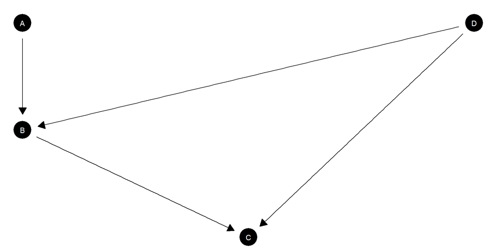

### 4.5.1 Key insight

The most powerful results from the study of DAGs give procedures for figuring out when conditioning aids or hinders causal identification.

- You can read off a **confounding** variable from a DAG.
  - You figure out what to condition on for causal identification.
- You can read off **“colliders”** from a DAG
  - Sometimes you have to *avoid* conditioning on these
- Sometimes a variable might be both, so
  - you have to condition on it
  - you have to avoid conditioning on it
  - Ouch.

### 4.5.2 Key resource

- Pearl’s book *Causality* is the key reference. Pearl (2009) (Though see also older work such as Pearl and Paz (1985))
- There is a lot of excellent material on Pearl’s page http://bayes.cs.ucla.edu/WHY/
- See also excellent material on Felix Elwert’s page http://www.ssc.wisc.edu/~felwert/causality/?page_id=66

### 4.5.3 Challenge for us

- Say you don’t like graphs. Fine.
- Consider this causal structure:
  - $Z = f_1(U_1, U_2)$
  - $X = f_2(U_2)$
  - $Y = f_3(X, U_1)$

Say $Z$ is temporally prior to $X$; it is correlated with $Y$ (because of $U_1$) and with $X$ (because of $U_2$).

**Question:** Would it be useful to “control” for $Z$ when trying to estimate the effect of $X$ on $Y$?

## 4.6 Challenge for us

- Say you don’t like graphs. Fine.
- Consider this causal structure:
  - $Z = f_1(U_1, U_2)$
  - $X = f_2(U_2)$
  - $Y = f_3(X, U_1)$

**Question:** Would it be useful to “control” for $Z$ when trying to estimate the effect of $X$ on $Y$?

**Answer:** Hopefully by the end of today you should see that the answer is obviously (or at least, plausibly) “no.”

## 4.7 Conditional independence and graph structure

- What DAGs do is tell you when one variable is independent of another variable given some third variable.
- Intuitively:
  - what variables “shield off” the influence of one variable on another
  - e.g. If inequality causes revolution *via* discontent, then inequality and revolution should be related to each other overall, but *not* related to each other *among those* that are content or *among those* that are discontent

### 4.7.1 Conditional independence

Variable sets $A$ and $B$ are conditionally independent, given $C$ if for all $a$, $b$, $c$:

$$\Pr(A = a | C = c) = \Pr(A = a | B = b, C = c)$$

Informally; given $C$, knowing $B$ tells you nothing more about $A$.

### 4.7.2 Conditional independence on paths graphs

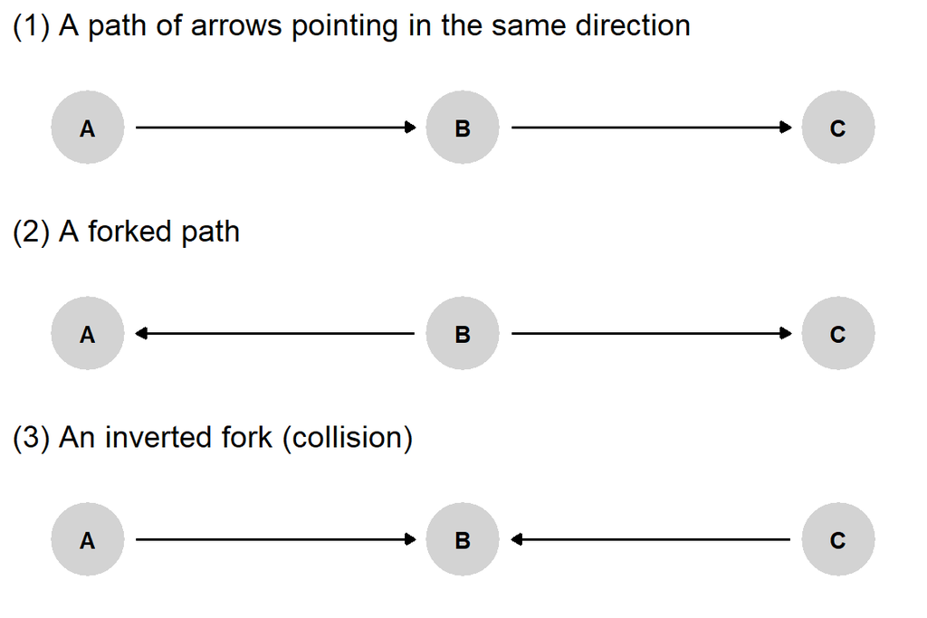

Three elemental relations of conditional independence.

### 4.7.3 Conditional independence from graphs

$A$ and $B$ are *conditionally independent*, given $C$ if on *every* path between $A$ and $B$:

- there is some chain ($\bullet\rightarrow \bullet\rightarrow\bullet$ or $\bullet\leftarrow \bullet\leftarrow\bullet$) or fork ($\bullet\leftarrow \bullet\rightarrow\bullet$) with the central element in $C$,

or

- there is an inverted fork ($\bullet\rightarrow \bullet\leftarrow\bullet$) with the central element (and its descendants) *not* in $C$

Notes:

- In this case we say that $A$ and $B$ are d-separated by $C$.
- $A$, $B$, and $C$ can all be sets
- Note that a path can involve arrows pointing any direction $\bullet\rightarrow \bullet\rightarrow \bullet\leftarrow \bullet\rightarrow\bullet$

### 4.7.4 Test yourself

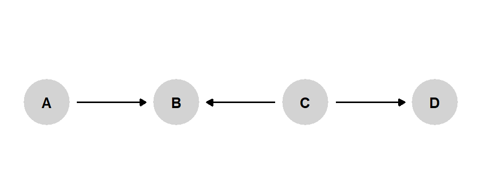

Are A and D unconditionally independent:

- if you do not condition on anything?
- if you condition on B?
- if you condition on C?
- if you condition on B and C?

### 4.7.5 Back to this example

- $Z = f_1(U_1, U_2)$
- $X = f_2(U_2)$
- $Y = f_3(X, U_1)$
1. Let’s graph this
2. Now: say we removed the arrow from $X$ to $Y$
   - Would you expect to see a correlation between $X$ and $Y$ if you did not control for $Z$
   - Would you expect to see a correlation between $X$ and $Y$ if you did control for $Z$

### 4.7.6 Back to this example

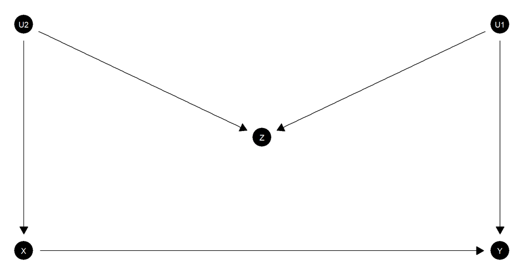

Now: say we removed the arrow from $X$ to $Y$

- Would you expect to see a correlation between $X$ and $Y$ if you did not control for $Z$?
- Would you expect to see a correlation between $X$ and $Y$ if you did control for $Z$?

### 4.7.7 Conditional distributions given `do` operations

We nor formalize things a little more:

- The probability of outcome $x$ can always be written in the form
  $$P(X_1 = x_1)P(X_2 = x_2|X_1=x_1)(X_3 = x_3|X_1=x_1, X_2 = x_2)\dots$$
- This can be done with any ordering of variables.
- We want to describe the distribution in a simpler way that takes account of *parent-child* relations and that can be used to capture interventions.

### 4.7.8 Conditional distributions given `do` operations

- Given an ordering of variables, the **Markovian parents** of variable $X_j$ are the minimal set of variables such that when you condition on these, $X_j$ is independent of all other prior variables in the ordering

$$P: P(x_1,x_2,\dots x_n) = \prod_{}P(x_j|pa_j)$$

- A DAG is “*causal Bayesian network*” or “*Causal DAG*” if (and only if) the probability distribution resulting from setting some set $X_i$ to $\hat{x}'_i$ (i.e. `do(X=x')`) is:

$$P_{\hat{x}_i}: P(x_1,x_2,\dots x_n|\hat{x}_i) = \mathbb{I}(x_i = x_i')\prod_{-i}P(x_j|pa_j)$$

*where the parents $pa_j$ are the parents on the graph* (parents of $x_i$ are the nodes with arrows pointing into $x_i$.)

### 4.7.9 Conditional distributions given `do` operations

So:

$$P_{\hat{x}_i}: P(x_1,x_2,\dots x_n|\hat{x}_i) = \mathbb{I}(x_i = x_i')\prod_{-i}P(x_j|pa_j)$$

- This means that there is only probability mass on vectors in which $x_i = x_i'$ (reflecting the success of control) and all other variables are determined by their parents, given the values that have been set for $x_i$.
- Such expressions will be critical later when we want to consider identificatation.
- They let us assess whether the probability of an outcome $y$, say, depends on the value of some other node, given some other node, or given *interventions* on some other node.

### 4.7.10 Conditional distributions given `do` operations

Illustration, say we have binary $X$ causes binary $M$ which cases binary $Y$; say we intervene and set $M=1$. Then what is the distribution of $(x,m,y)$?

It is:

$$\Pr(x,m,y) = \Pr(x)\mathbb I(M = 1)\Pr(y|m)$$

### 4.7.11 Application

We will use these ideas to motivate a general procedure for learning about, updating over, and querying, causal models.

## 4.8 Causal models

### 4.8.1 From graphs to Causal Models

A “**causal model**” is:

1.Variables

- An ordered list of $n$ endogenous nodes, $\mathcal{V}= (V^1, V^2,\dots, V^n)$, with a specification of a range for each of them
- A list of $n$ exogenous nodes, $\Theta = (\theta^1, \theta^2,\dots , \theta^n)$
2. A list of $n$ functions $\mathcal{F}= (f^1, f^2,\dots, f^n)$, one for each element of $\mathcal{V}$ such that each $f^i$ takes as arguments $\theta^i$ as well as elements of $\mathcal{V}$ that are *prior* to $V^i$ in the ordering
3. A probability distribution over $\Theta$

### 4.8.2 From graphs to Causal Models

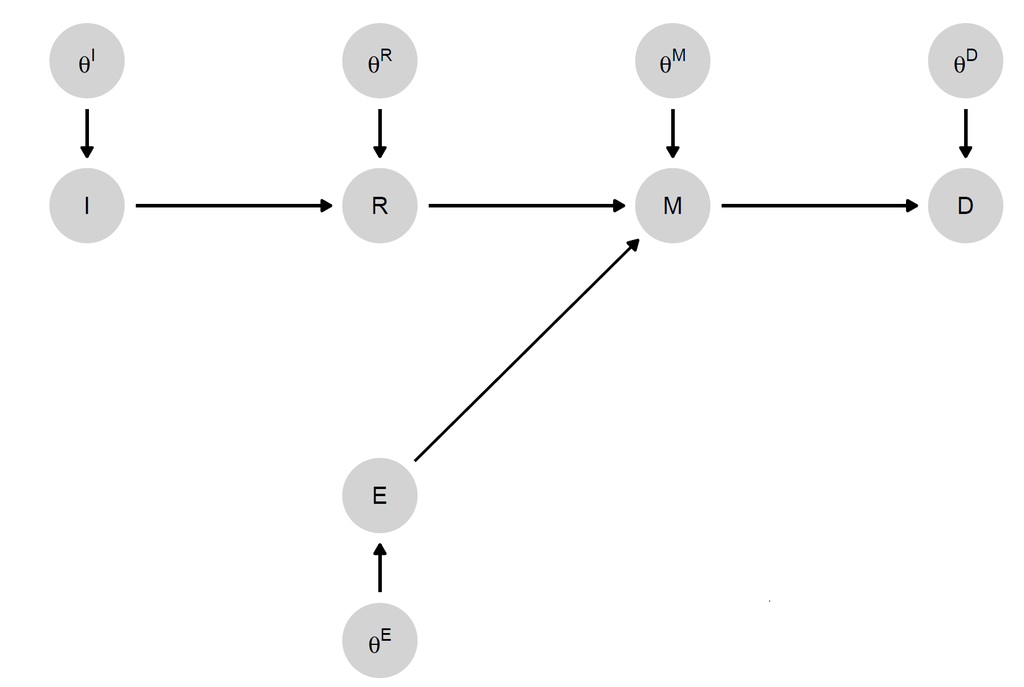

A simple causal model in which high inequality ($I$) affects democratization ($D$) via redistributive demands ($R$) and mass mobilization ($M$), which is also a function of ethnic homogeneity ($E$). Arrows show relations of causal dependence between variables.

### 4.8.3 Effects on a DAG

- Learning about effects *given* a model means learning about $F$ and *also* the distribution of shocks ($\Theta$).
- For discrete data this can be reduced to a question about learning about the distribution of $\Theta$ only.

### 4.8.4 Effects on a DAG

For instance the simplest model consistent with $X \rightarrow Y$:

- Endogenous Nodes = $\{X, Y\}$, both with range $\{0,1\}$
- Exogenous Nodes = $\{\theta^X, \theta^Y\}$, with ranges $\{\theta^X_0, \theta^X_1\}$ and $\{\theta^Y_{00}\theta^Y_{01}, \theta^Y_{10}, \theta^Y_{11}\}$
- Functional equations:
  - $f_Y$: $\theta^Y =\theta^Y_{ij} \rightarrow \{Y = i \text{ if } X=0; Y = j \text{ if } X=1\}$
  - $f_X$: $\theta^X =\theta^X_{i} \rightarrow \{X = i\}$
- Distributions on $\Theta$: $\Pr(\theta^i = \theta^i_k) = \lambda^i_k$

### 4.8.5 Effects as statement about exogeneous variables

What is the probability that $X$ has a positive causal effect on $Y$?

- This is equivalent to: $\Pr(\theta^Y =\theta^Y_{01}) = \lambda^Y_{01}$
- So we want to learn about the distributions of the exogenous nodes
- This general principle extends to a vast class of causal models

### 4.8.6 Recap: Things you need to know about causal inference

1. A causal claim is a statement about what didn’t happen.
2. If you know that $A$ causes $B$ and that $B$ causes $C$, this does not mean that you know that $A$ causes $C$.
3. There is no causation without manipulation.
4. There is a fundamental problem of causal inference.
5. You can estimate average causal effects even if you cannot observe any individual causal effects.
6. Estimating average causal effects via differences in means does not require that treatment and control groups are identical.
7. Estimating average causal effects via differences in means is fraught when you condition on post treatment variables or on colliders.

## 4.9 Estimands

*Estimation and testing*

## 4.10 Outline

- Types of estimands
- Principal strata
- Identification
- Backdoor
- Frontdoor
- `dagitty`

## 4.11 Estimands and inquiries

- Your **inquiry** is your question and the **estimand** is the true (generally unknown) answer to the inquiry
- The estimand is the thing you want to estimate
- If you are estimating something you should be able to say what your estimand is
- You are responsible for your estimand. Your estimator will not tell you what your estimand is
- Just because you can calculate something does not mean that you have an estimand
- You can test a hypothesis without having an estimand

Read: [II ch 4](https://macartan.github.io/integrated_inferences/HJC4.html), [DD, ch 7](https://book.declaredesign.org/declaration-diagnosis-redesign/defining-inquiry.html)

### 4.11.1 Estimands: ATE, ATT, ATC, S-, P-

- ATE is Average Treatment Effect (all units)
- ATT is Average Treatment Effect on the Treated
- ATC is Average Treatment Effect on the Controls

### 4.11.2 Estimands: ATE, ATT, ATC, S-, P-

Say that units are randomly assigned to treatment in different strata (maybe just one); with fixed, though possibly different, shares assigned in each stratum. Then the key estimands and estimators are:

| Estimand | Estimator |
| --- | --- |
| $\tau_{ATE} \equiv \mathbb{E}[\tau_i]$ | $\widehat{\tau}_{ATE} = \sum\nolimits_{x} \frac{w_x}{\sum\nolimits_{j}w_{j}}\widehat{\tau}_x$ |
| $\tau_{ATT} \equiv \mathbb{E}[\tau_i \| Z_i = 1]$ | $\widehat{\tau}_{ATT} = \sum\nolimits_{x} \frac{p_xw_x}{\sum\nolimits_{j}p_jw_j}\widehat{\tau}_x$ |
| $\tau_{ATC} \equiv \mathbb{E}[\tau_i \| Z_i = 0]$ | $\widehat{\tau}_{ATC} = \sum\nolimits_{x} \frac{(1-p_x)w_x}{\sum\nolimits_{j}(1-p_j)w_j}\widehat{\tau}_x$ |

where $x$ indexes strata, $p_x$ is the share of units in each stratum that is treated, and $w_x$ is the size of a stratum.

### 4.11.3 Estimands: ATE, ATT, ATC, S-, P-, C-

In addition, each of these can be targets of interest:

- for the **population**, in which case we refer to PATE, PATT, PATC and $\widehat{PATE}, \widehat{PATT}, \widehat{PATC}$
- for a **sample**, in which case we refer to SATE, SATT, SATC, and $\widehat{SATE}, \widehat{SATT}, \widehat{SATC}$

And for different subgroups,

- given some value on a covariate, in which case we refer to CATE (conditional average treatment effect)

### 4.11.4 Broader classes of estimands: LATE/CATE

The CATEs are **conditional** average treatment effects, for example the effect for men or for women. These are straightfoward.

However we might also imagine conditioning on unobservable or counterfactual features.

- The LATE (or CACE: “complier average causal effect”) asks about the effect of a treatment ($X$) on an outcome ($Y$) *for people that are responsive to an encouragement* ($Z$)

$$LATE = \frac{1}{|C|}\sum_{j\in C}(Y_j(X=1) - Y_j(X=0))$$
$$C:=\{j:X_j(Z=1) > X_j(Z=0) \}$$

We will return to these in the study of instrumental variables.

### 4.11.5 Quantile estimands

Other ways to condition on potential outcomes:

- A *quantile* treatment effect: You might be interested in the difference between the median $Y(1)$ and the median $Y(0)$ (Imbens and Rubin (2015) 20.3.1)
- or even be interested in the median $Y(1) - Y(0)$. Similarly for other quantiles.

### 4.11.6 Model estimands

Many inquiries are averages of individual effects, even if the groups are not known, but they do not have to be:

- The RDD estimand is a statement about what effects *would be* at a threshold; it can be defined under a model even if no actual individuals are at the threshold. We imagine average potential outcomes as a function of treatment $Z$ and running variable $X$, $f(z, x)$ and define:
  $$\tau_{RDD} := f(1, x^*) - f(0, x^*)$$

### 4.11.7 Distribution estimands

Many inquiries are averages of individual effects, even if the groups are not known,

But they do not have to be:

- Inquiries might relate to distributional quantities such as:
  - The effect of treatment on the variance in outcomes: $var(Y(1)) - var(Y(0))$
  - The variance of treatment effects: $var(Y(1) - Y(0))$
  - Other inequality measures (e.g. Ginis; (Imbens and Rubin (2015) 20.3.2))

You might even be interested in $\min(Y_i(1) - Y_i(0))$.

### 4.11.8 Spillover estimands

There are lots of interesting “spillover” estimands.

Imagine there are three individuals and each person’s outcomes depends on the assignments of all others. For instance $Y_1(Z_1, Z_2, Z_3$, or more generally, $Y_i(Z_i, Z_{i+1 (\text{mod }3)}, Z_{i+2 (\text{mod }3)})$.

Then three estimands might be:

- $\frac13\left(\sum_{i}{Y_i(1,0,0) - Y_i(0,0,0)}\right)$
- $\frac13\left(\sum_{i}{Y_i(1,1,1) - Y_i(0,0,0)}\right)$
- $\frac13\left(\sum_{i}{Y_i(0,1,1) - Y_i(0,0,0)}\right)$

Interpret these. What others might be of interest?

### 4.11.9 Differences in CATEs and interaction estimands

A difference in CATEs is a well defined estimand that might involve interventions on one node only:

- $\mathbb{E}_{\{W=1\}}[Y(X=1) - Y(X=0)] - \mathbb{E}_{\{W=0\}}[Y(X=1) - Y(X=0)]$

It captures differences in effects.

An *interaction* is an effect on an effect:

- $\mathbb{E}[Y(X=1, W=1) - Y(X=0, W=1)] - \mathbb{E}[Y(X=1, W=0) - Y(X=0, W=0)]$

Note in the latter the expectation is taken over the whole population.

### 4.11.10 Mediation estimands and complex counterfactuals

Say $X$ can affect $Y$ directly, or indirectly through $M$. then we can write potential outcomes as:

- $Y(X=x, M=m)$
- $M(X=x)$

We can then imagine inquiries of the form:

- $Y(X=1, M=M(X=1)) - Y(X=0, M=M(X=0))$
- $Y(X=1, M=1) - Y(X=0, M=1)$
- $Y(X=1, M=M(X=1)) - Y(X=1, M=M(X=0))$

Interpret these. What others might be of interest?

### 4.11.11 Mediation estimands and complex counterfactuals

Again we might imagine that these are defined with respect to some group:

- $A = \{i|Y_i(1, M(X=1)) > Y_i(0, M(X=0))\}$
- $\frac{1}{|A|} \sum_{i\in A}(Y(1, 1) > Y(0, 1))$

here, *among those for whom* $X$ has a positive effect on $Y$, for what share would there be a positive effect if $M$ were fixed at 1?

### 4.11.12 Causes of effects and effects of causes

In qualitative research a particularly common inquiry is “did $X=1$ cause $Y=1$?

This is often given as a probability, the “probability of causation” (though at the case level we might better think of this probability as an estimate rather than an estimand):

$$\Pr(Y_i(0) = 0 | Y_i(1) = 1, X = 1)$$

### 4.11.13 Causes of effects and effects of causes

Intuition: What’s the probability $X=1$ caused $Y=1$ in an $X=1, Y=1$ case drawn from a large population with the following experimental distribution:

|  | Y=0 | Y=1 | All |
| --- | --- | --- | --- |
| X=0 | 1 | 0 | 1 |
| X=1 | 0.25 | 0.75 | 1 |

### 4.11.14 Causes of effects and effects of causes

Intuition: What’s the probability $X=1$ caused $Y=1$ in an $X=1, Y=1$ case drawn from a large population with the following experimental distribution:

|  | Y=0 | Y=1 | All |
| --- | --- | --- | --- |
| X=0 | 0.75 | 0.25 | 1 |
| X=1 | 0.25 | 0.75 | 1 |

### 4.11.15 Actual causation

Other inquiries focus on distinguishing between causes.

For the Billy Suzy problem (Hall 2004), Halpern (2016) focuses on “actual causation” as a way to distinguish between Suzy and Billy:

> Imagine Suzy and Billy, simultaneously throwing stones at a bottle. Both are excellent shots and hit whatever they aim at. Suzy’s stone hits first, knocks over the bottle, and the bottle breaks. However, Billy’s stone *would* have hit had Suzy’s not hit, and again the bottle would have broken. Did Suzy’s throw cause the bottle to break? Did Billy’s?

### 4.11.16 Actual causation

Actual Causation:

1. $X=x$ and $Y=y$ both happened;
2. there is some set of variables, $\mathcal W$, such that if they were fixed at the levels that they *actually took* on in the case, and if $X$ were to be changed, then $Y$ would change (where $\mathcal W$ can also be an empty set);
3. no strict subset of $X$ satisfies 1 and 2 (there is no redundant part of the condition, $X=x$).

### 4.11.17 Actual causation

- Suzy: Condition 2 is met if Suzy’s throw made a difference, counterfactually speaking—with the important caveat that, in determining this, we are permitted to condition on Billy’ stone not hitting the bottle.
- Billy: Condition 2 is not met.

An inquiry: for what share in a population is a possible cause an actual cause?

### 4.11.18 Pearl’s ladder

Pearl (e.g. Pearl and Mackenzie (2018)) describes three types of inquiry:

| Level | Activity | Inquiry |
| --- | --- | --- |
| Association | “Seeing” | If I see $X=1$ should I expect $Y=1$? |
| Intervention | “Doing” | If I set $X$ to $1$ should I expect $Y=1$? |
| Counterfactual | “Imagining” | If $X$ were $0$ instead of 1, would $Y$ then be $0$ instead of $1$? |

### 4.11.19 Pearl’s ladder

We can understand these as asking different types of questions about a causal model

| Level | Activity | Inquiry |
| --- | --- | --- |
| Association | “Seeing” | $\Pr(Y=1\|X=1)$ |
| Intervention | “Doing” | $\mathbb{E}[\mathbb{I}(Y(1)=1)]$ |
| Counterfactual | “Imagining” | $\Pr(Y(1)=1 \& Y(0)=0)$ |

The third is qualitatively different because it requires information about two mutually incompatible conditions for units. This is not (generally ) recoverable directly from knowledge of $\Pr(Y(1)=1)$ and $\Pr(Y(0)=0)$.

## 4.12 Inquiries as statements about principal strata

Given a causal model over nodes with discrete ranges, inquiries can generally be described as summaries of the distributions of exogenous nodes.

We already saw two instances of this:

- The probability that $X$ has a positive effect on $Y$ in an $X \rightarrow Y$ model is $\lambda^Y_{01}$ (last lecture)
- The share of “compliers” in an IV model $Z \rightarrow X \rightarrow Y \leftrightarrow X$ is $\lambda^X_{01}$

## 4.13 Identification

*What it is. When you have it. What it’s worth.*

### 4.13.1 Identification

Informally a quantity is “identified” if it can be “recovered” once you have enough data.

Say for example average wage is $x$ in some very large population. If I gather lots and lots of data on the wages of individuals and take the average then then my estimate will ultimately let be figure out $x$.

- If $x$ is $1 then my estimate will end up centered on $1.
- If it is $2 it will end up centered on $2.

### 4.13.2 Identification (Definition)

- **Identifiability** Let $Q(M)$ be a query defined over a class of models $\mathcal M$, then $Q$ is identifiable if $P(M_1) = P(M_2) \rightarrow Q(M_1) = Q(M_1)$.
- **Identifiability with constrained data** Let $Q(M)$ be a query defined over a class of models $\mathcal M$, then $Q$ is identifiable from features $F(M)$ if $F(M_1) = F(M_2) \rightarrow Q(M_1) = Q(M_1)$.

Based on Defn 3.2.3 in Pearl.

- **Essentially**: Each underlying value produces a unique data distribution. When you see that distribution you recover the parameter.

### 4.13.3 Example without identification 1

Informally a quantity is “identified” if it can be “recovered” once you have enough data.

- Say for example average wage is $x^m$ for men and $x^w$ for women (in some very large population).
- If I gather lots and lots of data on the wages of (male and female) couples, e.g. $x^c_i = x^m_i + x^w_i$ then, although this will be informative, it will never be sufficient to recover $x^m$ for men and $x^w$.
- I can recover $x^c$, but there are too many combinations of possible values of $x^m$ and $x^w$ consistent with the observed data.

### 4.13.4 Example without identification 2

- share $a$ of units have negative effects
- $b$ have positive effects
- $c$ that always have $Y=0$ and
- $d$ always have $Y=1$.

Then with *very large* (experimental) data we observe:

|  | Y = 0 | Y = 1 |
| --- | --- | --- |
| **X = 0** | $\alpha_{00} \rightarrow b/2 + c/2$ | $\alpha_{01} \rightarrow a/2 + d/2$ |
| **X = 1** | $\alpha_{10} \rightarrow a/2 + c/2$ | $\alpha_{11} \rightarrow b/2 + d/2$ |

What quantities are identified?

- $b-a$?
- $d-c$?
- $b$?

### 4.13.5 Example without identification 2

What if we :

- *knew* that $a=0$
- *observed* that $\alpha_01=0$

|  | Y = 0 | Y = 1 |
| --- | --- | --- |
| **X = 0** | $\alpha_{00} \rightarrow b/2 + c/2$ | $\alpha_{01} \rightarrow a/2 + d/2$ |
| **X = 1** | $\alpha_{10} \rightarrow a/2 + c/2$ | $\alpha_{11} \rightarrow b/2 + d/2$ |

What quantities are now identified?

- $b-a$?
- $d-c$?
- $b$?

### 4.13.6 Identification : Goal

Our goal in causal inference is to estimate quantities such as:

$$\Pr(Y|\hat{x})$$

where $\hat{x}$ is interpreted as $X$ set to $x$ by “external” control. Equivalently: $do(X=x)$ or sometimes $X \leftarrow x$.

- If this quantity is **identifiable** then we can recover it with infinite data.
- If it is not identifiable, then, even in the best case, we are not guaranteed to get the right answer.

*Are there general rules for determining whether this quantity can be identified?* Yes.

### 4.13.7 Identification : Goal

Note first, identifying

$$\Pr(Y|x)$$

is easy.

But we are not always interested in identifying the distribution of $Y$ given *observed* values of $x$, but rather, the distribution of $Y$ if $X$ is *set* to $x$.

## 4.14 Levels and effects

If we can identify the controlled distribution we can calculate other causal quantities of interest.

For example for a binary $X, Y$ the causal effect of $X$ on the probability that $Y=1$ is:

$$\Pr(Y=1|\hat{x}=1) - \Pr(Y=1|\hat{x}=0)$$

Again, **this is not the same as**:

$$\Pr(Y=1|x=1) - \Pr(Y=1|x=0)$$

It’s the difference between seeing and doing.

### 4.14.1 When to condition? What to condition on?

The key idea is that you want to find a set of variables such that when you condition on these you get what you would get if you used a `do` operation.

Intuition:

- You could imagine creating a “mutilated” graph by removing all the arrows leading *out* of *X*
- Then select a set of variables, $Z$, such that $X$ and $Y$ are d-separated by $Z$ on the the mutilated graph
- When you condition on these you are making sure that any covariation between $X$ and $Y$ is covariation that is due to the effects of $X$

### 4.14.2 Illustration

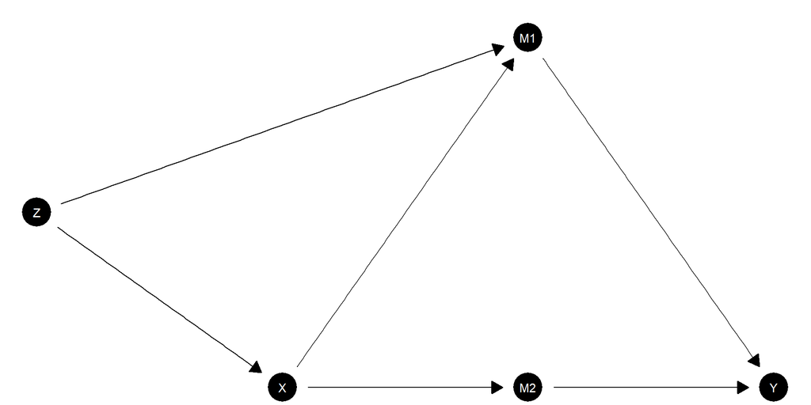

### 4.14.3 Illustration: Remove paths out

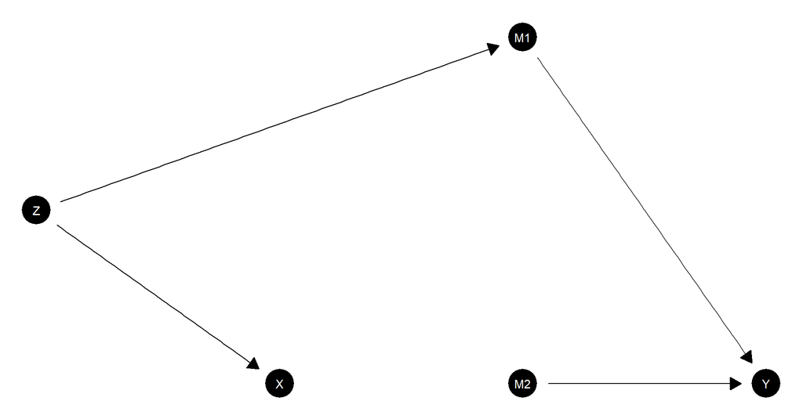

### 4.14.4 Illustration: Block backdoor path

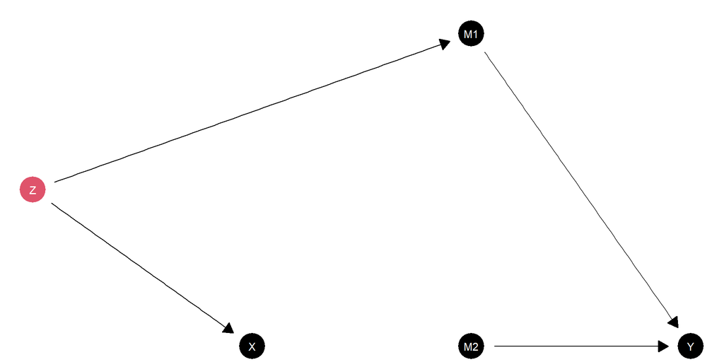

### 4.14.5 Illustration: Why not like this?

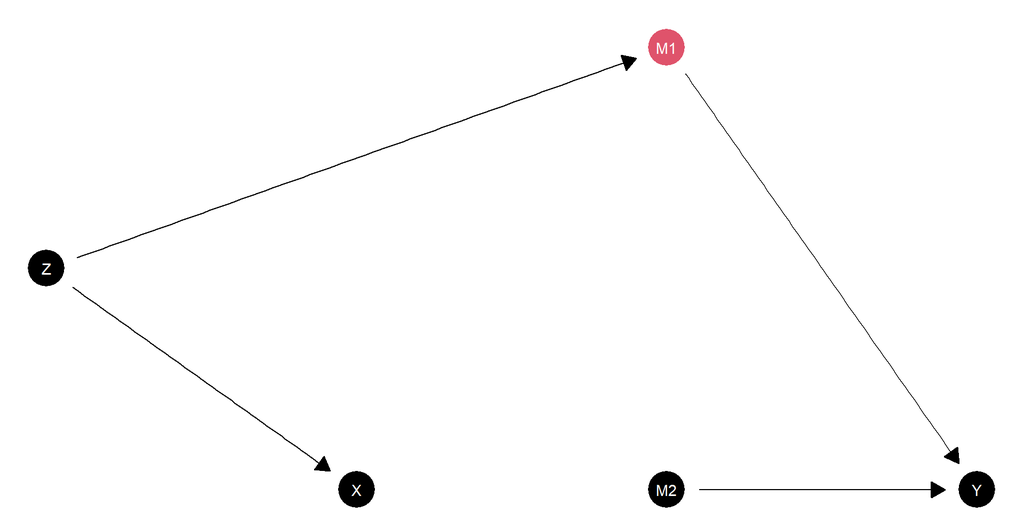

### 4.14.6 Identification

- Three results (“Graphical Identification Criteria”)
  - Backdoor criterion
  - Adjustment criterion
  - Frontdoor criterion
- There are more

### 4.14.7 Backdoor Criterion: (Pearl 1995)

The **backdoor criterion** is satisfied by $Z$ (relative to $X$, $Y$) if:

1. No node in $Z$ is a descendant of $X$
2. $Z$ blocks every **backdoor** path from $X$ to $Y$ (i.e. every path that contains an arrow into $X$)

In that case you can identify the effect of $X$ on $Y$ by conditioning on $Z$:

$$P(Y=y | \hat{x}) = \sum_z P(Y=y| X = x, Z=z)P(z)$$
(This is eqn 3.19 in Pearl (2000))

### 4.14.8 Backdoor Criterion: (Pearl 1995)

$$P(Y=y | \hat{x}) = \sum_z P(Y=y| X = x, Z=z)P(z)$$

- No notion of a linear control or anything like that; idea really is like blocking: think lots of discrete data and no missing patterns
- Note this is a formula for a (possibly counterfactual) *level*; a counterfactual difference would be given in the obvious way by:

$$P(Y=y | \hat{x}) - P(Y=y | \hat{x}')$$

### 4.14.9 Backdoor Proof

Following Pearl (2009), Chapter 11. Let $T$ denote the set of parents of $X$: $T := pa(X)$, with (possibly vector valued) realizations $t$. These might not all be observed.

If the backdoor criterion is satisfied, we have:

1. $Y$ is independent of $T$, given $X$ and observed data, $Z$ (since $Z$ blocks backdoor paths)
2. $X$ is independent of $Z$ given $T$. (Since $Z$ includes only nondescendents)
- **Key idea**: The intervention level relates to the observational level as follows:
  $$p(y|\hat{x}) = \sum_{t\in T} p(t)p(y|x, t)$$
- Think of this as *fully accounting for the (possibly unobserved) causes of $X$, $T$*

### 4.14.10 Backdoor Proof

We want to get to:

$$p(y|\hat{x}) = \sum_{t\in T} p(t)p(y|x, t)$$

- But of course we do not observe $T$, rather we observe $Z$. So we now need to write everything in terms of $Z$ rather than $T$.

We bring $Z$ into the picture by writing:

$$p(y|\hat{x}) = \sum_{t\in T} p(t) \sum_z p(y|x, t, z)p(z|x, t)$$

now we want to get rid of $T$…

### 4.14.11 Backdoor Proof

now we want to get rid of $T$…

- Using the two conditions from the backdoor definition above:
  1. replace $p(y|x, t, z)$ with $p(y | x, z)$
  2. replace $p(z|x, t)$ with $p(z|t)$

This gives:
$$p(y|\hat x) = \sum_{t \in T} p(t) \sum_z p(y|x, z)p(z|t)$$

Cleaning up, we can get rid of $T$:

$$p(y|\hat{x}) = \sum_z p(y|x, z)\sum_{t\in T} p(z|t)p(t) = \sum_z p(y| x, z)p(z)$$

### 4.14.12 Backdoor proof figure

For intuition:

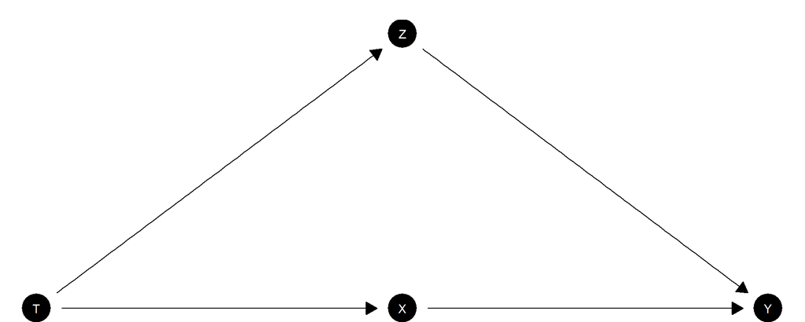

We would be happy if we could condition on the parent $T$, but $T$ is not observed. However we can use $Z$ instead making use of the fact that:

1. $p(y|x, t, z) = p(y | x, z)$ (since $Z$ blocks)
2. $p(z|x, t) = p(z|t)$ (since $Z$ is upstream and blocked by parents, $T$)

### 4.14.13 Adjustment criterion

See Shpitser, VanderWeele, and Robins (2012)

The adjustment criterion is satisfied by $Z$ (relative to $X$, $Y$) if:

1. no element of $Z$ is a descendant in the mutilated graph of any variable $W\not\in X$ which lies on a proper causal path from $X$ to $Y$
2. $Z$ blocks all **noncausal paths** from $X$ to $Y$

Note:

- mutilated graph: remove arrows pointing into $X$
- proper pathway: A *proper* causal pathway from $X$ to $Y$ only intersects $X$ at the endpoint

### 4.14.14 These are different. Simple illustration.

Here $Z$ satisfies the adjustment criterion but not the backdoor criterion:

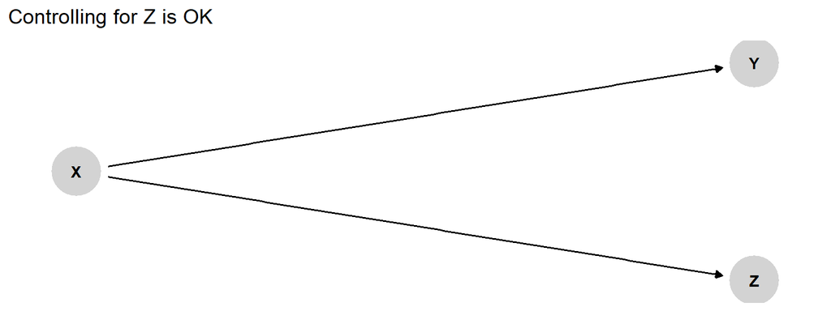

$Z$ is descendant of $X$ but it is not a descendant of a node on a path from $X$ to $Y$. No harm adjusting for $Z$ here, but not necessary either.

### 4.14.15 Frontdoor criterion (Pearl)

Consider this DAG:

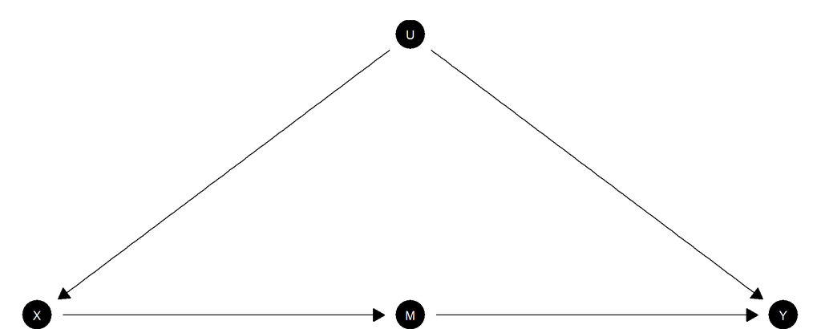

- The relationship between $X$ and $Y$ is confounded by $U$.
- However the $X\rightarrow Y$ effect is the product of the $X\rightarrow M$ effect and the $M\rightarrow Y$ effect

Why?

### 4.14.16 Identification through the front door

If:

- $M$ (possibly a set) blocks all *directed* paths from $X$ to $Y$
- there is no backdoor path $X$ to $M$
- $X$ blocks all backdoor paths from $M$ to $Y$ and
- all ($m,z$) combinations arise with positive probability

Then $\Pr(y| \hat x)$ is identifiable and given by:

$$\Pr(y| \hat x) = \sum_m\Pr(m|x)\sum_{x'}\left(\Pr(y|m,x')\Pr(x')\right)$$

### 4.14.17 Frontdoor criterion (Proof)

We want to get $\Pr(y | \hat x)$

From the graph the joint distribution of variables is:

$$\Pr(x,m,y,u) = \Pr(u)\Pr(x|u)\Pr(m|x)\Pr(y|m,u)$$
If we intervened on $X$ we would have ($\Pr(X = x |u)=1$):

$$\Pr(m,y,u | \hat x) = \Pr(u)\Pr(m|x)\Pr(y|m,u)$$
If we sum up over $u$ and $m$ we get:

$$\Pr(m,y| \hat x) = \Pr(m|x)\sum_u\left(\Pr(y|m,u)\Pr(u)\right)$$
$$\Pr(y| \hat x) = \sum_m\Pr(m|x)\sum_u\left(\Pr(y|m,u)\Pr(u)\right)$$

The first part is fine; the second part however involves $u$ which is unobserved. So we need to get the $u$ out of $\sum_u\left(\Pr(y|m,u)\Pr(u)\right)$.

### 4.14.18 Frontdoor criterion

Now, from the graph:

1. $M$ is d-separated from $U$ by $X$:

$$\Pr(u|m, x) = \Pr(u|x)$$
2. $X$ is d-separated from $Y$ by $M$, $U$

$$\Pr(y|x, m, u) = \Pr(y|m,u)$$
That’s enough to get $u$ out of $\sum_u\left(\Pr(y|m,u)\Pr(u)\right)$

### 4.14.19 Frontdoor criterion

$$\sum_u\left(\Pr(y|m,u)\Pr(u)\right) = \sum_x\sum_u\left(\Pr(y|m,u)\Pr(u|x)\Pr(x)\right)$$

Using the 2 equalities we got from the graph:

$$\sum_u\left(\Pr(y|m,u)\Pr(u)\right) = \sum_x\sum_u\left(\Pr(y|x,m,u)\Pr(u|x,m)\Pr(x)\right)$$

So:

$$\sum_u\left(\Pr(y|m,u)\Pr(u)\right) = \sum_x\left(\Pr(y|m,x)\Pr(x)\right)$$

Intuitively: $X$ blocks the back door between $Z$ and $Y$ just as well as $U$ does

### 4.14.20 Frontdoor criterion

Substituting we are left with:

$$\Pr(y| \hat x) = \sum_m\Pr(m|x)\sum_{x'}\left(\Pr(y|m,x')\Pr(x')\right)$$

(The $'$ is to distinguish the $x$ in the summation from the value of $x$ of interest)

It’s interesting that $x$ remains in the right hand side in the calculation of the $m \rightarrow y$ effect, but this is because $x$ blocks a backdoor from $m$ to $y$

### 4.14.21 Front foor

Bringing all this together into a claim we have:

If:

- $M$ (possibly a set) blocks all *directed* paths from $X$ to $Y$
- there is no backdoor path $X$ to $M$
- $X$ blocks all backdoor paths from $M$ to $Y$ and
- all ($m,z$) combinations arise with positive probability

Then $\Pr(y| \hat x)$ is identifiable and given by:

$$\Pr(y| \hat x) = \sum_m\Pr(m|x)\sum_{x'}\left(\Pr(y|m,x')\Pr(x')\right)$$

### 4.14.22 Front foor

- This is a very elegant and surprising result
- There are not many obvious applications of it however
- The conditions would be violated for example if unobserved third things caused both $M$ and $Y$

## 4.15 In code: Dagitty

There is a package (Textor et al. 2016) for figuring out what to condition on.

```r
library(dagitty)
```

### 4.15.1 In code: Dagitty

Define a dag using dagitty syntax:

```r
g <- dagitty("dag{X -> M -> Y ; Z -> X ; Z -> R -> Y}")
```

There is then a simple command to check whether two sets are d-separated by a third set:

```r
dseparated(g, "X", "Y", "M")
```

```
[1] FALSE
```

```r
dseparated(g, "X", "Y", c("Z","M"))
```

```
[1] TRUE
```

### 4.15.2 Dagitty: Find adjustment sets

And a simple command to identify the adjustments needed to identify the effect of one variable on another:

```r
adjustmentSets(g, exposure = "X", outcome = "Y")
```

```
{ R }
{ Z }
```

### 4.15.3 Important Examples : Confounding

Example where $Z$ is correlated with $X$ and $Y$ and is a confounder

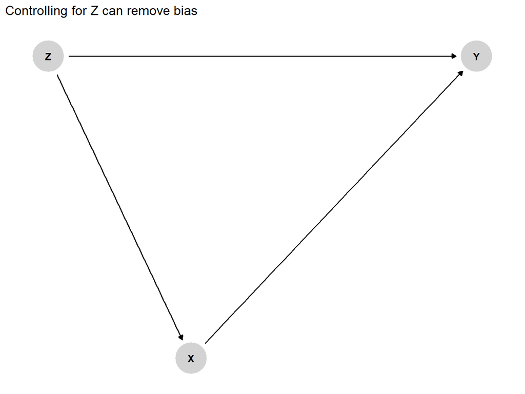

### 4.15.4 Confounding

Example where $Z$ is correlated with $X$ and $Y$ but it is *not* a confounder

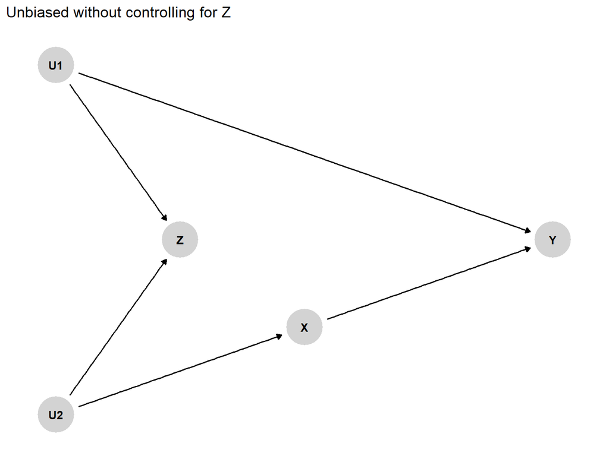